# S_van_Mesdag_Biodiversity_Analyses_1

Savanna van Mesdag

2023-08-29

##The following is written by Savanna van Mesdag, going through the relevant coding and analyses for the biodiversity analyses for the six anthropogenic substrate study sites.

#setwd#

#To run the following code to carry out the analyses, the following packages must be installed#

```r
install.packages("iNEXT", repos =   "http://chao.stat.nthu.edu.tw/wordpress/software_download/")
install.packages('devtools', repos = "https://github.com/r-lib/devtools")
install.packages('AnneChao/iNEXT', repos =  "http://chao.stat.nthu.edu.tw/wordpress/software_download/")
install.packages("ggthemes", repos = "https://github.com/jrnold/ggthemes")
install.packages("vegan", repos = " https://github.com/vegandevs/vegan")
```

##The packages also need to be loaded prior to running the analyses and producing graphs#

```r
library(devtools)
```

```r
library(iNEXT)
library(ggplot2)
library(ggthemes)
library(vegan)
```

#Loading Barrow data

```r
urlfile1 <- 'https://raw.githubusercontent.com/Savannankvm/Biodiversity-analyses-for-six-study-sites/PhD-files/Barrow_Abundance_Data.csv?token=GHSAT0AAAAAACG4POBNQ6K6T4V5KYG6HMXSZHOAFWQ'

Barrow_Nos <-read.csv(urlfile1)
```

#To look at the Barrow data#

```r
print(Barrow_Nos)
```

```
##    Quadrat.1 Quadrat.2 Quadrat.3 Quadrat.4 Quadrat.5 Quadrat.6 Quadrat.7
## 1          4         0       127         0        32         0         0
## 2          0         0         0         0         0         0         1
## 3          0         0         0         0         0         8         0
## 4          4         6         1         0         6         0         0
## 5          0         0         0         0         0         0         0
## 6          0        30         0         0         0         0         0
## 7          0        30         0         0         0         0         0
## 8          0         0       138         9         8         0         0
## 9          0         0         0         0         0         1         0
## 10         0        30        20       110         0         0        10
## 11         0         0         0         0         0         0       120
## 12         0         0         0         0         0         0         0
## 13         0         0         0         0         0         0         0
## 14         0         0         1         2         1         0         1
```

[output cut: 97 more lines]

#colSums to establish sample size for each of the quadrats.

```r
colSums(Barrow_Nos)
```

```
##  Quadrat.1  Quadrat.2  Quadrat.3  Quadrat.4  Quadrat.5  Quadrat.6  Quadrat.7
##        132        444        446        294        277        464        328
##  Quadrat.8  Quadrat.9 Quadrat.10 Quadrat.11
##        428         82        250        155
```

#Setting m to sample size for Quadrat 1 (132 individuals.) This will give me observed #qD value that will be most representative for Quadrat and Community. Will do the same #for the other 10 communities below.

```r
m <- c(132)

Barrow_Datam <- iNEXT(Barrow_Nos, q=c(0), datatype= "abundance", size = m)

Barrow_Datam
```

```
## Compare 11 assemblages with Hill number order q = 0.
## $class: iNEXT
##
## $DataInfo: basic data information
##    Assemblage   n S.obs     SC f1 f2 f3 f4 f5 f6 f7 f8 f9 f10
## 1   Quadrat.1 132    10 0.9925  1  1  1  3  0  0  0  1  0   0
## 2   Quadrat.2 444    14 1.0000  0  1  1  0  1  1  0  0  0   0
## 3   Quadrat.3 446    14 0.9888  5  0  0  1  0  0  0  0  0   1
## 4   Quadrat.4 294    12 0.9898  3  1  0  0  0  0  0  1  1   0
## 5   Quadrat.5 277    19 0.9893  3  5  4  1  0  1  0  1  0   0
## 6   Quadrat.6 464    10 0.9935  3  1  1  0  0  0  0  1  0   0
## 7   Quadrat.7 328    15 0.9909  3  5  0  0  0  0  0  0  0   2
## 8   Quadrat.8 428    14 0.9977  1  2  1  0  1  0  1  0  0   0
## 9   Quadrat.9  82    16 0.9527  4  5  2  1  1  1  0  0  0   0
## 10 Quadrat.10 250    10 0.9920  2  1  0  0  3  0  0  0  0   1
```

[output cut: 204 more lines]

```r
Barrow_Datam_1 <- iNEXT(Barrow_Nos, q=c(0,1,2), datatype= "abundance", size = m)

Barrow_Datam_1
```

```
## Compare 11 assemblages with Hill number order q = 0, 1, 2.
## $class: iNEXT
##
## $DataInfo: basic data information
##    Assemblage   n S.obs     SC f1 f2 f3 f4 f5 f6 f7 f8 f9 f10
## 1   Quadrat.1 132    10 0.9925  1  1  1  3  0  0  0  1  0   0
## 2   Quadrat.2 444    14 1.0000  0  1  1  0  1  1  0  0  0   0
## 3   Quadrat.3 446    14 0.9888  5  0  0  1  0  0  0  0  0   1
## 4   Quadrat.4 294    12 0.9898  3  1  0  0  0  0  0  1  1   0
## 5   Quadrat.5 277    19 0.9893  3  5  4  1  0  1  0  1  0   0
## 6   Quadrat.6 464    10 0.9935  3  1  1  0  0  0  0  1  0   0
## 7   Quadrat.7 328    15 0.9909  3  5  0  0  0  0  0  0  0   2
## 8   Quadrat.8 428    14 0.9977  1  2  1  0  1  0  1  0  0   0
## 9   Quadrat.9  82    16 0.9527  4  5  2  1  1  1  0  0  0   0
## 10 Quadrat.10 250    10 0.9920  2  1  0  0  3  0  0  0  0   1
```

[output cut: 554 more lines]

```r
n <- c(444)

Barrow_Datan <- iNEXT(Barrow_Nos, q=c(0), datatype= "abundance", size = n)

Barrow_Datan
```

```
## Compare 11 assemblages with Hill number order q = 0.
## $class: iNEXT
##
## $DataInfo: basic data information
##    Assemblage   n S.obs     SC f1 f2 f3 f4 f5 f6 f7 f8 f9 f10
## 1   Quadrat.1 132    10 0.9925  1  1  1  3  0  0  0  1  0   0
## 2   Quadrat.2 444    14 1.0000  0  1  1  0  1  1  0  0  0   0
## 3   Quadrat.3 446    14 0.9888  5  0  0  1  0  0  0  0  0   1
## 4   Quadrat.4 294    12 0.9898  3  1  0  0  0  0  0  1  1   0
## 5   Quadrat.5 277    19 0.9893  3  5  4  1  0  1  0  1  0   0
## 6   Quadrat.6 464    10 0.9935  3  1  1  0  0  0  0  1  0   0
## 7   Quadrat.7 328    15 0.9909  3  5  0  0  0  0  0  0  0   2
## 8   Quadrat.8 428    14 0.9977  1  2  1  0  1  0  1  0  0   0
## 9   Quadrat.9  82    16 0.9527  4  5  2  1  1  1  0  0  0   0
## 10 Quadrat.10 250    10 0.9920  2  1  0  0  3  0  0  0  0   1
```

[output cut: 204 more lines]

```r
o <- c(446)

Barrow_Datao <- iNEXT(Barrow_Nos, q=c(0), datatype= "abundance", size = o)

Barrow_Datao
```

```
## Compare 11 assemblages with Hill number order q = 0.
## $class: iNEXT
##
## $DataInfo: basic data information
##    Assemblage   n S.obs     SC f1 f2 f3 f4 f5 f6 f7 f8 f9 f10
## 1   Quadrat.1 132    10 0.9925  1  1  1  3  0  0  0  1  0   0
## 2   Quadrat.2 444    14 1.0000  0  1  1  0  1  1  0  0  0   0
## 3   Quadrat.3 446    14 0.9888  5  0  0  1  0  0  0  0  0   1
## 4   Quadrat.4 294    12 0.9898  3  1  0  0  0  0  0  1  1   0
## 5   Quadrat.5 277    19 0.9893  3  5  4  1  0  1  0  1  0   0
## 6   Quadrat.6 464    10 0.9935  3  1  1  0  0  0  0  1  0   0
## 7   Quadrat.7 328    15 0.9909  3  5  0  0  0  0  0  0  0   2
## 8   Quadrat.8 428    14 0.9977  1  2  1  0  1  0  1  0  0   0
## 9   Quadrat.9  82    16 0.9527  4  5  2  1  1  1  0  0  0   0
## 10 Quadrat.10 250    10 0.9920  2  1  0  0  3  0  0  0  0   1
```

[output cut: 202 more lines]

```r
p <- c(294)

Barrow_Datap <- iNEXT(Barrow_Nos, q=c(0), datatype= "abundance", size = p)

Barrow_Datap
```

```
## Compare 11 assemblages with Hill number order q = 0.
## $class: iNEXT
##
## $DataInfo: basic data information
##    Assemblage   n S.obs     SC f1 f2 f3 f4 f5 f6 f7 f8 f9 f10
## 1   Quadrat.1 132    10 0.9925  1  1  1  3  0  0  0  1  0   0
## 2   Quadrat.2 444    14 1.0000  0  1  1  0  1  1  0  0  0   0
## 3   Quadrat.3 446    14 0.9888  5  0  0  1  0  0  0  0  0   1
## 4   Quadrat.4 294    12 0.9898  3  1  0  0  0  0  0  1  1   0
## 5   Quadrat.5 277    19 0.9893  3  5  4  1  0  1  0  1  0   0
## 6   Quadrat.6 464    10 0.9935  3  1  1  0  0  0  0  1  0   0
## 7   Quadrat.7 328    15 0.9909  3  5  0  0  0  0  0  0  0   2
## 8   Quadrat.8 428    14 0.9977  1  2  1  0  1  0  1  0  0   0
## 9   Quadrat.9  82    16 0.9527  4  5  2  1  1  1  0  0  0   0
## 10 Quadrat.10 250    10 0.9920  2  1  0  0  3  0  0  0  0   1
```

[output cut: 203 more lines]

```r
q <- c(277)

Barrow_Dataq <- iNEXT(Barrow_Nos, q=c(0), datatype= "abundance", size = q)

Barrow_Dataq
```

```
## Compare 11 assemblages with Hill number order q = 0.
## $class: iNEXT
##
## $DataInfo: basic data information
##    Assemblage   n S.obs     SC f1 f2 f3 f4 f5 f6 f7 f8 f9 f10
## 1   Quadrat.1 132    10 0.9925  1  1  1  3  0  0  0  1  0   0
## 2   Quadrat.2 444    14 1.0000  0  1  1  0  1  1  0  0  0   0
## 3   Quadrat.3 446    14 0.9888  5  0  0  1  0  0  0  0  0   1
## 4   Quadrat.4 294    12 0.9898  3  1  0  0  0  0  0  1  1   0
## 5   Quadrat.5 277    19 0.9893  3  5  4  1  0  1  0  1  0   0
## 6   Quadrat.6 464    10 0.9935  3  1  1  0  0  0  0  1  0   0
## 7   Quadrat.7 328    15 0.9909  3  5  0  0  0  0  0  0  0   2
## 8   Quadrat.8 428    14 0.9977  1  2  1  0  1  0  1  0  0   0
## 9   Quadrat.9  82    16 0.9527  4  5  2  1  1  1  0  0  0   0
## 10 Quadrat.10 250    10 0.9920  2  1  0  0  3  0  0  0  0   1
```

[output cut: 203 more lines]

```r
r <- c(464)

Barrow_Datar <- iNEXT(Barrow_Nos, q=c(0), datatype= "abundance", size = r)

Barrow_Datar
```

```
## Compare 11 assemblages with Hill number order q = 0.
## $class: iNEXT
##
## $DataInfo: basic data information
##    Assemblage   n S.obs     SC f1 f2 f3 f4 f5 f6 f7 f8 f9 f10
## 1   Quadrat.1 132    10 0.9925  1  1  1  3  0  0  0  1  0   0
## 2   Quadrat.2 444    14 1.0000  0  1  1  0  1  1  0  0  0   0
## 3   Quadrat.3 446    14 0.9888  5  0  0  1  0  0  0  0  0   1
## 4   Quadrat.4 294    12 0.9898  3  1  0  0  0  0  0  1  1   0
## 5   Quadrat.5 277    19 0.9893  3  5  4  1  0  1  0  1  0   0
## 6   Quadrat.6 464    10 0.9935  3  1  1  0  0  0  0  1  0   0
## 7   Quadrat.7 328    15 0.9909  3  5  0  0  0  0  0  0  0   2
## 8   Quadrat.8 428    14 0.9977  1  2  1  0  1  0  1  0  0   0
## 9   Quadrat.9  82    16 0.9527  4  5  2  1  1  1  0  0  0   0
## 10 Quadrat.10 250    10 0.9920  2  1  0  0  3  0  0  0  0   1
```

[output cut: 202 more lines]

```r
s <- c(328)

Barrow_Datas <- iNEXT(Barrow_Nos, q=c(0), datatype= "abundance", size = s)

Barrow_Datas
```

```
## Compare 11 assemblages with Hill number order q = 0.
## $class: iNEXT
##
## $DataInfo: basic data information
##    Assemblage   n S.obs     SC f1 f2 f3 f4 f5 f6 f7 f8 f9 f10
## 1   Quadrat.1 132    10 0.9925  1  1  1  3  0  0  0  1  0   0
## 2   Quadrat.2 444    14 1.0000  0  1  1  0  1  1  0  0  0   0
## 3   Quadrat.3 446    14 0.9888  5  0  0  1  0  0  0  0  0   1
## 4   Quadrat.4 294    12 0.9898  3  1  0  0  0  0  0  1  1   0
## 5   Quadrat.5 277    19 0.9893  3  5  4  1  0  1  0  1  0   0
## 6   Quadrat.6 464    10 0.9935  3  1  1  0  0  0  0  1  0   0
## 7   Quadrat.7 328    15 0.9909  3  5  0  0  0  0  0  0  0   2
## 8   Quadrat.8 428    14 0.9977  1  2  1  0  1  0  1  0  0   0
## 9   Quadrat.9  82    16 0.9527  4  5  2  1  1  1  0  0  0   0
## 10 Quadrat.10 250    10 0.9920  2  1  0  0  3  0  0  0  0   1
```

[output cut: 203 more lines]

```r
t <- c(428)

Barrow_Datat <- iNEXT(Barrow_Nos, q=c(0), datatype= "abundance", size = t)

Barrow_Datat
```

```
## Compare 11 assemblages with Hill number order q = 0.
## $class: iNEXT
##
## $DataInfo: basic data information
##    Assemblage   n S.obs     SC f1 f2 f3 f4 f5 f6 f7 f8 f9 f10
## 1   Quadrat.1 132    10 0.9925  1  1  1  3  0  0  0  1  0   0
## 2   Quadrat.2 444    14 1.0000  0  1  1  0  1  1  0  0  0   0
## 3   Quadrat.3 446    14 0.9888  5  0  0  1  0  0  0  0  0   1
## 4   Quadrat.4 294    12 0.9898  3  1  0  0  0  0  0  1  1   0
## 5   Quadrat.5 277    19 0.9893  3  5  4  1  0  1  0  1  0   0
## 6   Quadrat.6 464    10 0.9935  3  1  1  0  0  0  0  1  0   0
## 7   Quadrat.7 328    15 0.9909  3  5  0  0  0  0  0  0  0   2
## 8   Quadrat.8 428    14 0.9977  1  2  1  0  1  0  1  0  0   0
## 9   Quadrat.9  82    16 0.9527  4  5  2  1  1  1  0  0  0   0
## 10 Quadrat.10 250    10 0.9920  2  1  0  0  3  0  0  0  0   1
```

[output cut: 203 more lines]

```r
u <- c(82)

Barrow_Datau <- iNEXT(Barrow_Nos, q=c(0), datatype= "abundance", size = u)

Barrow_Datau
```

```
## Compare 11 assemblages with Hill number order q = 0.
## $class: iNEXT
##
## $DataInfo: basic data information
##    Assemblage   n S.obs     SC f1 f2 f3 f4 f5 f6 f7 f8 f9 f10
## 1   Quadrat.1 132    10 0.9925  1  1  1  3  0  0  0  1  0   0
## 2   Quadrat.2 444    14 1.0000  0  1  1  0  1  1  0  0  0   0
## 3   Quadrat.3 446    14 0.9888  5  0  0  1  0  0  0  0  0   1
## 4   Quadrat.4 294    12 0.9898  3  1  0  0  0  0  0  1  1   0
## 5   Quadrat.5 277    19 0.9893  3  5  4  1  0  1  0  1  0   0
## 6   Quadrat.6 464    10 0.9935  3  1  1  0  0  0  0  1  0   0
## 7   Quadrat.7 328    15 0.9909  3  5  0  0  0  0  0  0  0   2
## 8   Quadrat.8 428    14 0.9977  1  2  1  0  1  0  1  0  0   0
## 9   Quadrat.9  82    16 0.9527  4  5  2  1  1  1  0  0  0   0
## 10 Quadrat.10 250    10 0.9920  2  1  0  0  3  0  0  0  0   1
```

[output cut: 204 more lines]

```r
v <- c(250)

Barrow_Datav <- iNEXT(Barrow_Nos, q=c(0), datatype= "abundance", size = v)

Barrow_Datav
```

```
## Compare 11 assemblages with Hill number order q = 0.
## $class: iNEXT
##
## $DataInfo: basic data information
##    Assemblage   n S.obs     SC f1 f2 f3 f4 f5 f6 f7 f8 f9 f10
## 1   Quadrat.1 132    10 0.9925  1  1  1  3  0  0  0  1  0   0
## 2   Quadrat.2 444    14 1.0000  0  1  1  0  1  1  0  0  0   0
## 3   Quadrat.3 446    14 0.9888  5  0  0  1  0  0  0  0  0   1
## 4   Quadrat.4 294    12 0.9898  3  1  0  0  0  0  0  1  1   0
## 5   Quadrat.5 277    19 0.9893  3  5  4  1  0  1  0  1  0   0
## 6   Quadrat.6 464    10 0.9935  3  1  1  0  0  0  0  1  0   0
## 7   Quadrat.7 328    15 0.9909  3  5  0  0  0  0  0  0  0   2
## 8   Quadrat.8 428    14 0.9977  1  2  1  0  1  0  1  0  0   0
## 9   Quadrat.9  82    16 0.9527  4  5  2  1  1  1  0  0  0   0
## 10 Quadrat.10 250    10 0.9920  2  1  0  0  3  0  0  0  0   1
```

[output cut: 203 more lines]

```r
w <- c(155)

Barrow_Dataw <- iNEXT(Barrow_Nos, q=c(0), datatype= "abundance", size = w)

Barrow_Dataw
```

```
## Compare 11 assemblages with Hill number order q = 0.
## $class: iNEXT
##
## $DataInfo: basic data information
##    Assemblage   n S.obs     SC f1 f2 f3 f4 f5 f6 f7 f8 f9 f10
## 1   Quadrat.1 132    10 0.9925  1  1  1  3  0  0  0  1  0   0
## 2   Quadrat.2 444    14 1.0000  0  1  1  0  1  1  0  0  0   0
## 3   Quadrat.3 446    14 0.9888  5  0  0  1  0  0  0  0  0   1
## 4   Quadrat.4 294    12 0.9898  3  1  0  0  0  0  0  1  1   0
## 5   Quadrat.5 277    19 0.9893  3  5  4  1  0  1  0  1  0   0
## 6   Quadrat.6 464    10 0.9935  3  1  1  0  0  0  0  1  0   0
## 7   Quadrat.7 328    15 0.9909  3  5  0  0  0  0  0  0  0   2
## 8   Quadrat.8 428    14 0.9977  1  2  1  0  1  0  1  0  0   0
## 9   Quadrat.9  82    16 0.9527  4  5  2  1  1  1  0  0  0   0
## 10 Quadrat.10 250    10 0.9920  2  1  0  0  3  0  0  0  0   1
```

[output cut: 206 more lines]

#Now to run the analysis again without specificying the size, can do this for #looking at the other diversity indices#

```r
Barrow_Data <- iNEXT(Barrow_Nos, q=c(0), datatype= "abundance")

Barrow_Data
```

```
## Compare 11 assemblages with Hill number order q = 0.
## $class: iNEXT
##
## $DataInfo: basic data information
##    Assemblage   n S.obs     SC f1 f2 f3 f4 f5 f6 f7 f8 f9 f10
## 1   Quadrat.1 132    10 0.9925  1  1  1  3  0  0  0  1  0   0
## 2   Quadrat.2 444    14 1.0000  0  1  1  0  1  1  0  0  0   0
## 3   Quadrat.3 446    14 0.9888  5  0  0  1  0  0  0  0  0   1
## 4   Quadrat.4 294    12 0.9898  3  1  0  0  0  0  0  1  1   0
## 5   Quadrat.5 277    19 0.9893  3  5  4  1  0  1  0  1  0   0
## 6   Quadrat.6 464    10 0.9935  3  1  1  0  0  0  0  1  0   0
## 7   Quadrat.7 328    15 0.9909  3  5  0  0  0  0  0  0  0   2
## 8   Quadrat.8 428    14 0.9977  1  2  1  0  1  0  1  0  0   0
## 9   Quadrat.9  82    16 0.9527  4  5  2  1  1  1  0  0  0   0
## 10 Quadrat.10 250    10 0.9920  2  1  0  0  3  0  0  0  0   1
```

[output cut: 306 more lines]

```r
Barrow_Data_1 <- iNEXT(Barrow_Nos, q=c(1), datatype = "abundance")

Barrow_Data_1
```

```
## Compare 11 assemblages with Hill number order q = 1.
## $class: iNEXT
##
## $DataInfo: basic data information
##    Assemblage   n S.obs     SC f1 f2 f3 f4 f5 f6 f7 f8 f9 f10
## 1   Quadrat.1 132    10 0.9925  1  1  1  3  0  0  0  1  0   0
## 2   Quadrat.2 444    14 1.0000  0  1  1  0  1  1  0  0  0   0
## 3   Quadrat.3 446    14 0.9888  5  0  0  1  0  0  0  0  0   1
## 4   Quadrat.4 294    12 0.9898  3  1  0  0  0  0  0  1  1   0
## 5   Quadrat.5 277    19 0.9893  3  5  4  1  0  1  0  1  0   0
## 6   Quadrat.6 464    10 0.9935  3  1  1  0  0  0  0  1  0   0
## 7   Quadrat.7 328    15 0.9909  3  5  0  0  0  0  0  0  0   2
## 8   Quadrat.8 428    14 0.9977  1  2  1  0  1  0  1  0  0   0
## 9   Quadrat.9  82    16 0.9527  4  5  2  1  1  1  0  0  0   0
## 10 Quadrat.10 250    10 0.9920  2  1  0  0  3  0  0  0  0   1
```

[output cut: 250 more lines]

#Now to look at further things, such as sample coverage#

```r
Barrowout1 <- estimateD(Barrow_Nos, q = c(0,1,2), datatype = "abundance", base="size")
Barrowout1
```

```
##    Assemblage   m        Method Order.q        SC        qD    qD.LCL    qD.UCL
## 1   Quadrat.1 164 Extrapolation       0 0.9954051 10.190652  8.100828 12.280477
## 2   Quadrat.1 164 Extrapolation       1 0.9954051  4.952234  3.987533  5.916936
## 3   Quadrat.1 164 Extrapolation       2 0.9954051  3.305054  2.533973  4.076134
## 4   Quadrat.2 164   Rarefaction       0 0.9912442 13.189205 12.416490 13.961920
## 5   Quadrat.2 164   Rarefaction       1 0.9912442  9.559224  9.117205 10.001243
## 6   Quadrat.2 164   Rarefaction       2 0.9912442  8.118355  7.642962  8.593748
## 7   Quadrat.3 164   Rarefaction       0 0.9861054 10.668601  9.078462 12.258740
## 8   Quadrat.3 164   Rarefaction       1 0.9861054  5.668334  5.241128  6.095539
## 9   Quadrat.3 164   Rarefaction       2 0.9861054  4.416538  4.116465  4.716611
## 10  Quadrat.4 164   Rarefaction       0 0.9866832 10.476948  8.934794 12.019101
## 11  Quadrat.4 164   Rarefaction       1 0.9866832  6.220335  5.553406  6.887263
## 12  Quadrat.4 164   Rarefaction       2 0.9866832  4.714842  3.976765  5.452918
## 13  Quadrat.5 164   Rarefaction       0 0.9662006 16.649438 14.397445 18.901431
## 14  Quadrat.5 164   Rarefaction       1 0.9662006  4.932905  4.138787  5.727023
```

[output cut: 19 more lines]

```r
Barrowout2 <- estimateD(Barrow_Nos, q = c(0,1,2), datatype = "abundance", base="coverage")
Barrowout2
```

```
##    Assemblage        m        Method Order.q        SC        qD    qD.LCL
## 1   Quadrat.1 138.2628 Extrapolation       0 0.9932137 10.044922  6.342696
## 2   Quadrat.1 138.2628 Extrapolation       1 0.9932137  4.918588  3.960696
## 3   Quadrat.1 138.2628 Extrapolation       2 0.9932137  3.296376  2.544970
## 4   Quadrat.2 190.4990   Rarefaction       0 0.9932137 13.394898 12.672915
## 5   Quadrat.2 190.4990   Rarefaction       1 0.9932137  9.617527  9.011628
## 6   Quadrat.2 190.4990   Rarefaction       2 0.9932137  8.167971  7.476919
## 7   Quadrat.3 892.0000 Extrapolation       0 0.9932137 17.930966  6.764204
## 8   Quadrat.3 892.0000 Extrapolation       1 0.9932137  5.910085  5.365996
## 9   Quadrat.3 892.0000 Extrapolation       2 0.9932137  4.493405  4.164549
## 10  Quadrat.4 472.4666 Extrapolation       0 0.9932137 13.495319  8.423662
## 11  Quadrat.4 472.4666 Extrapolation       1 0.9932137  6.403789  5.668152
## 12  Quadrat.4 472.4666 Extrapolation       2 0.9932137  4.786056  4.121641
## 13  Quadrat.5 314.9374 Extrapolation       0 0.9932137 19.328057 10.629086
## 14  Quadrat.5 314.9374 Extrapolation       1 0.9932137  5.103273  4.271010
```

[output cut: 53 more lines]

#Looking at species evenness using the vegan package#

```r
H <- diversity(Barrow_Nos)

Bevenness <- H/log(specnumber(Barrow_Nos))

summary(Bevenness)
```

```
##    Min. 1st Qu.  Median    Mean 3rd Qu.    Max.    NA's
##  0.1435  0.6500  0.7629  0.7022  0.8691  1.0000      22
```

```r
H1 <- diversity(Barrow_Nos$Quadrat.1)

Bevenness1 <- H1/log(specnumber(Barrow_Nos$Quadrat.1))

summary(Bevenness1)
```

```
##    Min. 1st Qu.  Median    Mean 3rd Qu.    Max.
##   0.691   0.691   0.691   0.691   0.691   0.691
```

```r
H2 <- diversity(Barrow_Nos$Quadrat.2)

Bevenness2 <- H2/log(specnumber(Barrow_Nos$Quadrat.2))

summary(Bevenness2)
```

```
##    Min. 1st Qu.  Median    Mean 3rd Qu.    Max.
##  0.8658  0.8658  0.8658  0.8658  0.8658  0.8658
```

```r
H3 <- diversity(Barrow_Nos$Quadrat.3)

Bevenness3 <- H3/log(specnumber(Barrow_Nos$Quadrat.3))

summary(Bevenness3)
```

```
##    Min. 1st Qu.  Median    Mean 3rd Qu.    Max.
##  0.6679  0.6679  0.6679  0.6679  0.6679  0.6679
```

```r
H4 <- diversity(Barrow_Nos$Quadrat.4)

Bevenness4 <- H4/log(specnumber(Barrow_Nos$Quadrat.4))

summary(Bevenness4)
```

```
##    Min. 1st Qu.  Median    Mean 3rd Qu.    Max.
##  0.7427  0.7427  0.7427  0.7427  0.7427  0.7427
```

```r
H5 <- diversity(Barrow_Nos$Quadrat.5)

Bevenness5 <- H5/log(specnumber(Barrow_Nos$Quadrat.5))

summary(Bevenness5)
```

```
##    Min. 1st Qu.  Median    Mean 3rd Qu.    Max.
##  0.5518  0.5518  0.5518  0.5518  0.5518  0.5518
```

```r
H6 <- diversity(Barrow_Nos$Quadrat.6)

Bevenness6 <- H6/log(specnumber(Barrow_Nos$Quadrat.6))

summary(Bevenness6)
```

```
##    Min. 1st Qu.  Median    Mean 3rd Qu.    Max.
##  0.6325  0.6325  0.6325  0.6325  0.6325  0.6325
```

```r
H7 <- diversity(Barrow_Nos$Quadrat.7)

Bevenness7 <- H7/log(specnumber(Barrow_Nos$Quadrat.7))

summary(Bevenness7)
```

```
##    Min. 1st Qu.  Median    Mean 3rd Qu.    Max.
##  0.6864  0.6864  0.6864  0.6864  0.6864  0.6864
```

```r
H8 <- diversity(Barrow_Nos$Quadrat.8)

Bevenness8 <- H8/log(specnumber(Barrow_Nos$Quadrat.8))

summary(Bevenness8)
```

```
##    Min. 1st Qu.  Median    Mean 3rd Qu.    Max.
##  0.6941  0.6941  0.6941  0.6941  0.6941  0.6941
```

```r
H9 <- diversity(Barrow_Nos$Quadrat.9)

Bevenness9 <- H9/log(specnumber(Barrow_Nos$Quadrat.9))

summary(Bevenness9)
```

```
##    Min. 1st Qu.  Median    Mean 3rd Qu.    Max.
##  0.7698  0.7698  0.7698  0.7698  0.7698  0.7698
```

```r
H10 <- diversity(Barrow_Nos$Quadrat.10)

Bevenness10 <- H10/log(specnumber(Barrow_Nos$Quadrat.10))

summary(Bevenness10)
```

```
##    Min. 1st Qu.  Median    Mean 3rd Qu.    Max.
##  0.6408  0.6408  0.6408  0.6408  0.6408  0.6408
```

```r
H11 <- diversity(Barrow_Nos$Quadrat.11)

Bevenness11 <- H11/log(specnumber(Barrow_Nos$Quadrat.11))

summary(Bevenness11)
```

```
##    Min. 1st Qu.  Median    Mean 3rd Qu.    Max.
##  0.8426  0.8426  0.8426  0.8426  0.8426  0.8426
```

##Now to generate graphs to better visually examine species curves etc##

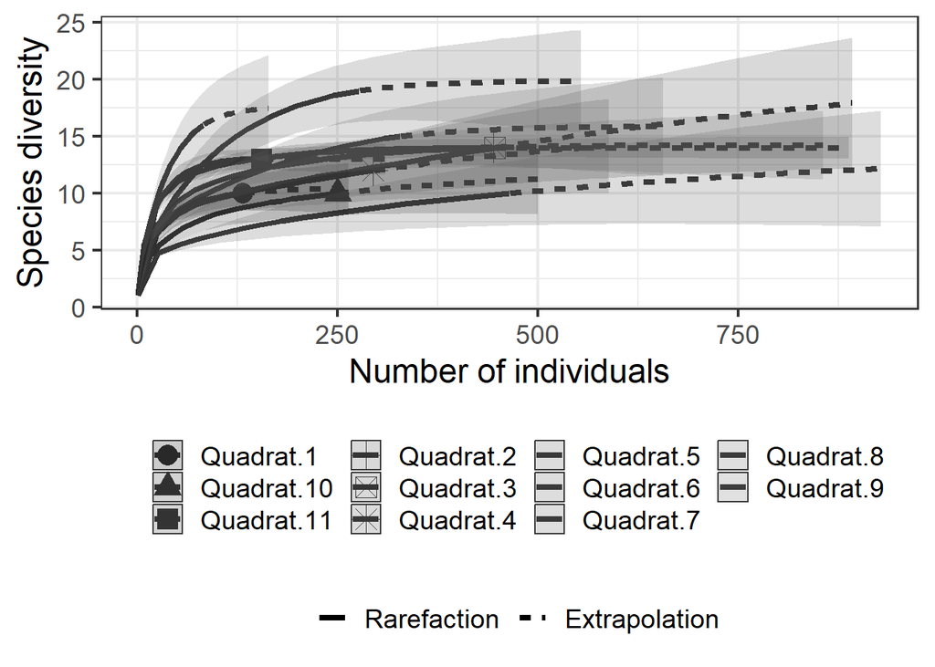

```r
Barrow_Data_Graph1 <- ggiNEXT(x = Barrow_Data, se=TRUE, type = 1,
                              facet.var = "None", grey=TRUE)
Barrow_Data_Graph1
```

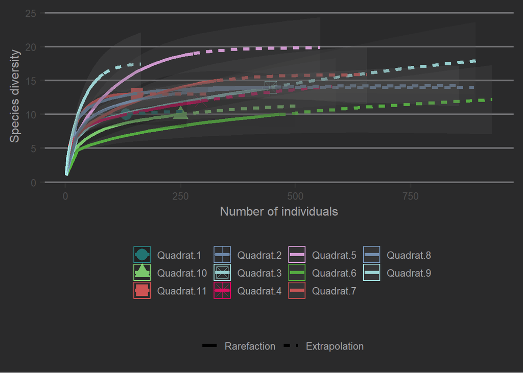

```r
g7 <- Barrow_Data_Graph1 + theme_hc(style = "darkunica") +
  scale_colour_hc("darkunica")
g7
```

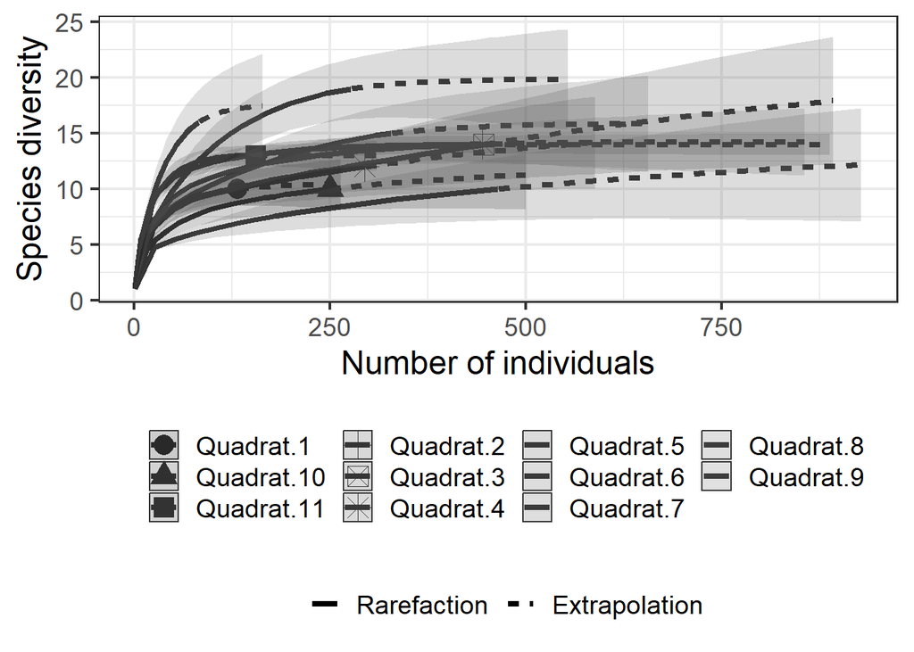

```r
Barrow_Data_Graph2 <- ggiNEXT(x = Barrow_Data, se=TRUE, type = 1,
                              facet.var="None", grey= TRUE)
Barrow_Data_Graph2
```

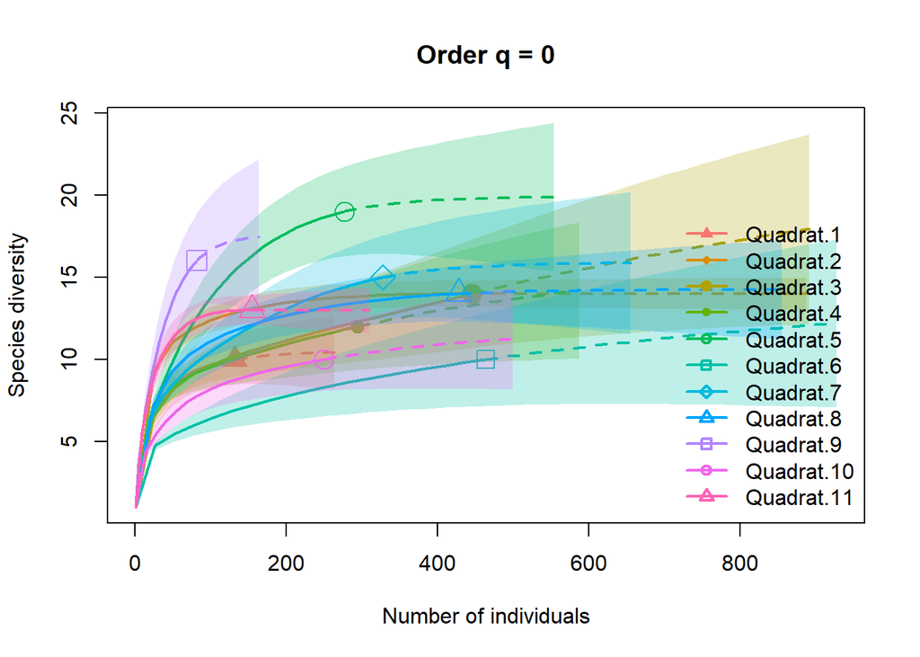

```r
plot(Barrow_Data, type=1)
```

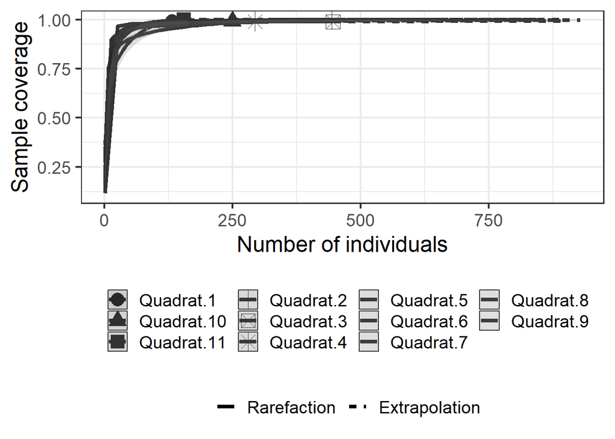

```r
Barrow_Data_Graph3 <- ggiNEXT(x = Barrow_Data, se=TRUE, type = 2,
                              facet.var="None", grey = TRUE)
Barrow_Data_Graph3
```

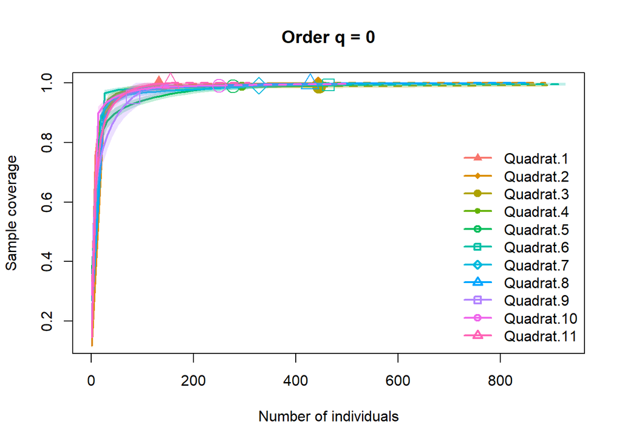

```r
plot(Barrow_Data, type=2)
```

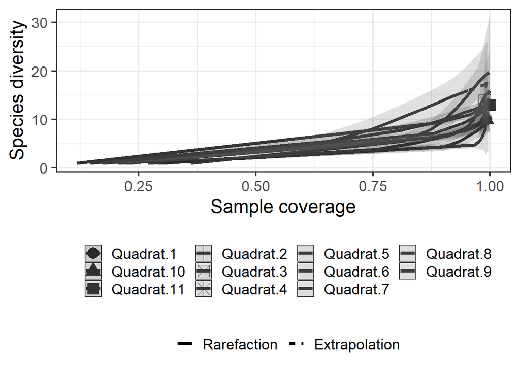

```r
Barrow_Data_Graph4 <- ggiNEXT(x = Barrow_Data, se=TRUE, type = 3,
                              facet.var="None", grey= TRUE)
Barrow_Data_Graph4
```

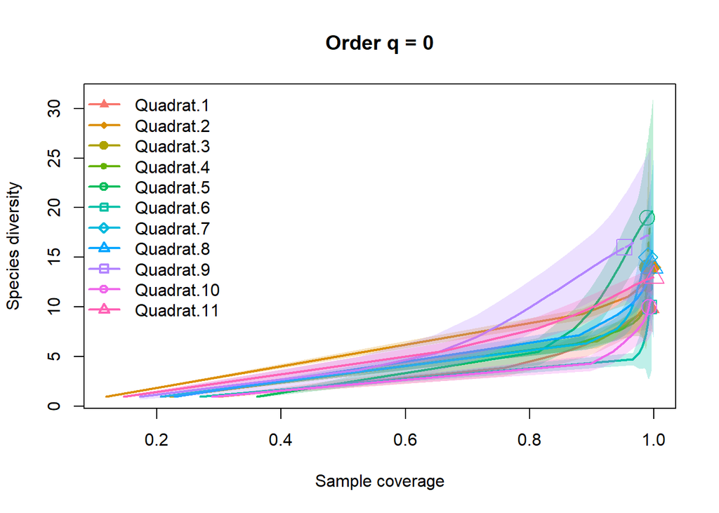

```r
plot(Barrow_Data, type=3)
```

##Fallin Data##

```r
urlfile2 <- 'https://raw.githubusercontent.com/Savannankvm/Biodiversity-analyses-for-six-study-sites/PhD-files/Fallin_Abundance_Data.csv'

Fallin_Nos <-read.csv(urlfile2)

print(Fallin_Nos)
```

```
##     Quadrat_1 Quadrat_2 Quadrat_3 Quadrat_4 Quadrat_5
## 1           0         9         1         0         0
## 2           0         0         0         0         0
## 3           0         0         0         0         0
## 4           0         0         0         0         0
## 5           0         0         0         0         0
## 6          81        18         8        82        55
## 7           0         0         0         0         0
## 8           0         0         0         0         0
## 9           0         0         0         2        42
## 10          0         0         0         0        10
## 11          0         0         0         0         0
## 12          1         0         8        16         0
## 13          0         0        12         0         0
## 14          0         0         0         0         0
```

[output cut: 129 more lines]

#colSums to establish sample size for each of the quadrats.

```r
colSums(Fallin_Nos)
```

```
## Quadrat_1 Quadrat_2 Quadrat_3 Quadrat_4 Quadrat_5
##       711       525       639       820       798
```

#Setting m to sample size for Quadrat 1. This will give me observed #qD value that will be most representative for Quadrat and Community. Will do the same #for the other communities below.

```r
m <- c(711)

Fallin_Datam <- iNEXT(Fallin_Nos, q=c(0), datatype= "abundance", size = m)

Fallin_Datam
```

```
## Compare 5 assemblages with Hill number order q = 0.
## $class: iNEXT
##
## $DataInfo: basic data information
##   Assemblage   n S.obs     SC f1 f2 f3 f4 f5 f6 f7 f8 f9 f10
## 1  Quadrat_1 711    18 0.9958  3  0  1  1  0  0  0  0  0   0
## 2  Quadrat_2 525    17 1.0000  0  0  0  0  1  1  0  0  1   3
## 3  Quadrat_3 639    23 0.9969  2  3  0  0  0  1  0  2  0   7
## 4  Quadrat_4 820    18 0.9976  2  1  0  1  0  0  1  0  0   3
## 5  Quadrat_5 798    19 0.9962  3  1  0  0  0  0  0  0  0   1
##
## $iNextEst: diversity estimates with rarefied and extrapolated samples.
## $size_based (LCL and UCL are obtained for fixed size.)
##
##    Assemblage   m        Method Order.q       qD   qD.LCL   qD.UCL        SC
```

[output cut: 91 more lines]

```r
n <- c(525)

Fallin_Datan <- iNEXT(Fallin_Nos, q=c(0), datatype= "abundance", size = n)

Fallin_Datan
```

```
## Compare 5 assemblages with Hill number order q = 0.
## $class: iNEXT
##
## $DataInfo: basic data information
##   Assemblage   n S.obs     SC f1 f2 f3 f4 f5 f6 f7 f8 f9 f10
## 1  Quadrat_1 711    18 0.9958  3  0  1  1  0  0  0  0  0   0
## 2  Quadrat_2 525    17 1.0000  0  0  0  0  1  1  0  0  1   3
## 3  Quadrat_3 639    23 0.9969  2  3  0  0  0  1  0  2  0   7
## 4  Quadrat_4 820    18 0.9976  2  1  0  1  0  0  1  0  0   3
## 5  Quadrat_5 798    19 0.9962  3  1  0  0  0  0  0  0  0   1
##
## $iNextEst: diversity estimates with rarefied and extrapolated samples.
## $size_based (LCL and UCL are obtained for fixed size.)
##
##    Assemblage   m        Method Order.q       qD   qD.LCL   qD.UCL        SC
```

[output cut: 94 more lines]

```r
o <- c(639)

Fallin_Datao <- iNEXT(Fallin_Nos, q=c(0), datatype= "abundance", size = o)

Fallin_Datao
```

```
## Compare 5 assemblages with Hill number order q = 0.
## $class: iNEXT
##
## $DataInfo: basic data information
##   Assemblage   n S.obs     SC f1 f2 f3 f4 f5 f6 f7 f8 f9 f10
## 1  Quadrat_1 711    18 0.9958  3  0  1  1  0  0  0  0  0   0
## 2  Quadrat_2 525    17 1.0000  0  0  0  0  1  1  0  0  1   3
## 3  Quadrat_3 639    23 0.9969  2  3  0  0  0  1  0  2  0   7
## 4  Quadrat_4 820    18 0.9976  2  1  0  1  0  0  1  0  0   3
## 5  Quadrat_5 798    19 0.9962  3  1  0  0  0  0  0  0  0   1
##
## $iNextEst: diversity estimates with rarefied and extrapolated samples.
## $size_based (LCL and UCL are obtained for fixed size.)
##
##    Assemblage   m        Method Order.q       qD   qD.LCL   qD.UCL        SC
```

[output cut: 91 more lines]

```r
p <- c(820)

Fallin_Datap <- iNEXT(Fallin_Nos, q=c(0), datatype= "abundance", size = p)

Fallin_Datap
```

```
## Compare 5 assemblages with Hill number order q = 0.
## $class: iNEXT
##
## $DataInfo: basic data information
##   Assemblage   n S.obs     SC f1 f2 f3 f4 f5 f6 f7 f8 f9 f10
## 1  Quadrat_1 711    18 0.9958  3  0  1  1  0  0  0  0  0   0
## 2  Quadrat_2 525    17 1.0000  0  0  0  0  1  1  0  0  1   3
## 3  Quadrat_3 639    23 0.9969  2  3  0  0  0  1  0  2  0   7
## 4  Quadrat_4 820    18 0.9976  2  1  0  1  0  0  1  0  0   3
## 5  Quadrat_5 798    19 0.9962  3  1  0  0  0  0  0  0  0   1
##
## $iNextEst: diversity estimates with rarefied and extrapolated samples.
## $size_based (LCL and UCL are obtained for fixed size.)
##
##    Assemblage   m        Method Order.q       qD   qD.LCL   qD.UCL        SC
```

[output cut: 91 more lines]

```r
q <- c(798)

Fallin_Dataq <- iNEXT(Fallin_Nos, q=c(0), datatype= "abundance", size = q)

Fallin_Dataq
```

```
## Compare 5 assemblages with Hill number order q = 0.
## $class: iNEXT
##
## $DataInfo: basic data information
##   Assemblage   n S.obs     SC f1 f2 f3 f4 f5 f6 f7 f8 f9 f10
## 1  Quadrat_1 711    18 0.9958  3  0  1  1  0  0  0  0  0   0
## 2  Quadrat_2 525    17 1.0000  0  0  0  0  1  1  0  0  1   3
## 3  Quadrat_3 639    23 0.9969  2  3  0  0  0  1  0  2  0   7
## 4  Quadrat_4 820    18 0.9976  2  1  0  1  0  0  1  0  0   3
## 5  Quadrat_5 798    19 0.9962  3  1  0  0  0  0  0  0  0   1
##
## $iNextEst: diversity estimates with rarefied and extrapolated samples.
## $size_based (LCL and UCL are obtained for fixed size.)
##
##    Assemblage   m        Method Order.q       qD   qD.LCL   qD.UCL        SC
```

[output cut: 91 more lines]

#Now to run the analysis again for Fallin without specificying the size, can do this for #looking at the other diversity indices

```r
Fallin_Data <- iNEXT(Fallin_Nos, q=c(0), datatype= "abundance")

Fallin_Data
```

```
## Compare 5 assemblages with Hill number order q = 0.
## $class: iNEXT
##
## $DataInfo: basic data information
##   Assemblage   n S.obs     SC f1 f2 f3 f4 f5 f6 f7 f8 f9 f10
## 1  Quadrat_1 711    18 0.9958  3  0  1  1  0  0  0  0  0   0
## 2  Quadrat_2 525    17 1.0000  0  0  0  0  1  1  0  0  1   3
## 3  Quadrat_3 639    23 0.9969  2  3  0  0  0  1  0  2  0   7
## 4  Quadrat_4 820    18 0.9976  2  1  0  1  0  0  1  0  0   3
## 5  Quadrat_5 798    19 0.9962  3  1  0  0  0  0  0  0  0   1
##
## $iNextEst: diversity estimates with rarefied and extrapolated samples.
## $size_based (LCL and UCL are obtained for fixed size.)
##
##     Assemblage    m        Method Order.q       qD   qD.LCL   qD.UCL         SC
```

[output cut: 144 more lines]

```r
F1 <- diversity(Fallin_Nos$Quadrat_1)
```

#Now to do other analyses to generate further biodiversity indices for Fallin, including coverage

```r
Fallin2 <- estimateD(Fallin_Nos, q = c(0,1,2), datatype = "abundance", base="coverage")
Fallin2
```

```
##    Assemblage         m        Method Order.q        SC        qD    qD.LCL
## 1   Quadrat_1 1266.6741 Extrapolation       0 0.9980725 19.625362 14.996248
## 2   Quadrat_1 1266.6741 Extrapolation       1 0.9980725 10.621084 10.126700
## 3   Quadrat_1 1266.6741 Extrapolation       2 0.9980725  8.389826  7.742133
## 4   Quadrat_2  232.8222   Rarefaction       0 0.9980725 16.905394 16.826185
## 5   Quadrat_2  232.8222   Rarefaction       1 0.9980725 11.022989 10.207929
## 6   Quadrat_2  232.8222   Rarefaction       2 0.9980725  8.205068  7.231886
## 7   Quadrat_3  741.3429 Extrapolation       0 0.9980725 23.253791 19.245390
## 8   Quadrat_3  741.3429 Extrapolation       1 0.9980725 10.909101  9.895418
## 9   Quadrat_3  741.3429 Extrapolation       2 0.9980725  7.684717  6.837757
## 10  Quadrat_4 1011.9098 Extrapolation       0 0.9980725 18.417051 15.178425
## 11  Quadrat_4 1011.9098 Extrapolation       1 0.9980725  9.121107  8.590401
## 12  Quadrat_4 1011.9098 Extrapolation       2 0.9980725  7.147556  6.749009
## 13  Quadrat_5 1596.0000 Extrapolation       0 0.9980725 21.188165 15.699138
## 14  Quadrat_5 1596.0000 Extrapolation       1 0.9980725 12.621079 11.894762
```

[output cut: 17 more lines]

#Now to do vegan analyses for species evenness for Fallin data

```r
Fevenness1 <- F1/log(specnumber(Fallin_Nos$Quadrat_1))

summary(Fevenness1)
```

```
##    Min. 1st Qu.  Median    Mean 3rd Qu.    Max.
##  0.8148  0.8148  0.8148  0.8148  0.8148  0.8148
```

```r
F2 <- diversity(Fallin_Nos$Quadrat_2)

Fevenness2 <- F2/log(specnumber(Fallin_Nos$Quadrat_2))

summary(Fevenness2)
```

```
##    Min. 1st Qu.  Median    Mean 3rd Qu.    Max.
##  0.8542  0.8542  0.8542  0.8542  0.8542  0.8542
```

```r
F3 <- diversity(Fallin_Nos$Quadrat_3)

Fevenness3 <- F3/log(specnumber(Fallin_Nos$Quadrat_3))

summary(Fevenness3)
```

```
##    Min. 1st Qu.  Median    Mean 3rd Qu.    Max.
##  0.7612  0.7612  0.7612  0.7612  0.7612  0.7612
```

```r
F4 <- diversity(Fallin_Nos$Quadrat_4)

Fevenness4 <- F4/log(specnumber(Fallin_Nos$Quadrat_4))

summary(Fevenness4)
```

```
##    Min. 1st Qu.  Median    Mean 3rd Qu.    Max.
##  0.7639  0.7639  0.7639  0.7639  0.7639  0.7639
```

```r
F5 <- diversity(Fallin_Nos$Quadrat_5)

Fevenness5 <- F5/log(specnumber(Fallin_Nos$Quadrat_5))

summary(Fevenness5)
```

```
##    Min. 1st Qu.  Median    Mean 3rd Qu.    Max.
##  0.8581  0.8581  0.8581  0.8581  0.8581  0.8581
```

#Now to generate some graphs for Fallin data for better visualisation, including to visualise species curves#

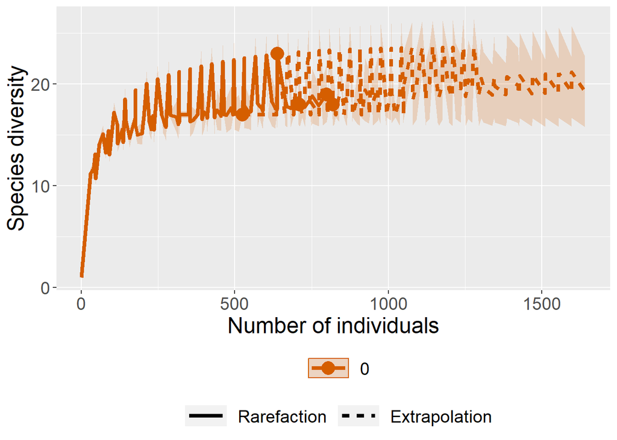

```r
Fallin_Data_Graph1 <- ggiNEXT(x = Fallin_Data, se=TRUE, color.var="Order.q")

Fallin_Data_Graph1
```

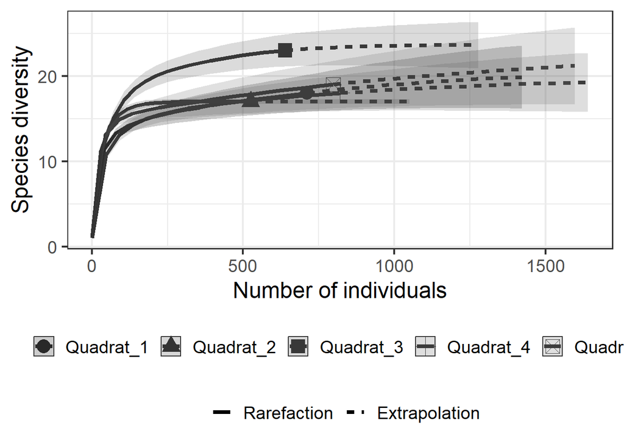

```r
Fallin_Data_Graph1.1 <- ggiNEXT(x = Fallin_Data, se=TRUE, type = 1,
                                facet.var="None", grey=TRUE)
Fallin_Data_Graph1.1
```

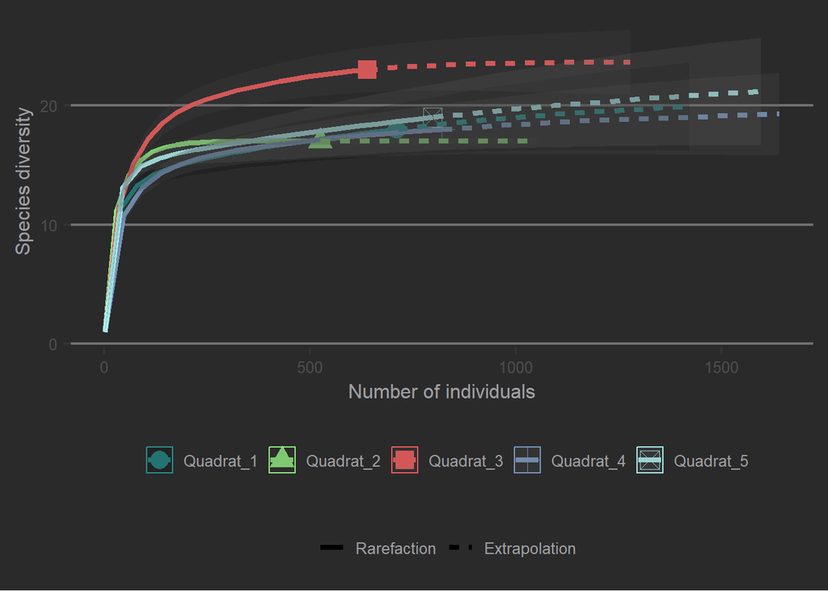

```r
Falling <- Fallin_Data_Graph1.1 + theme_hc(style = "darkunica") +
  scale_colour_hc("darkunica")
Falling
```

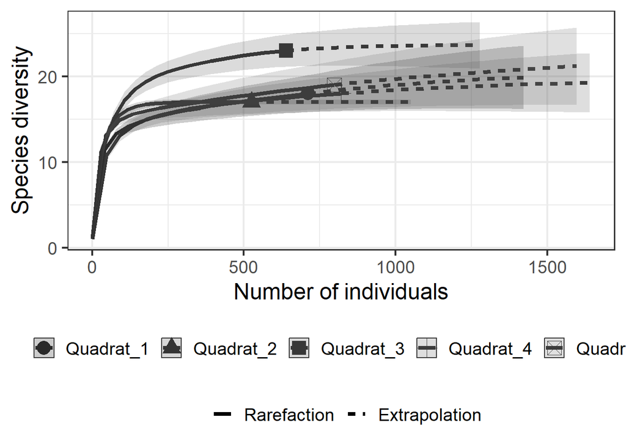

```r
Fallin_Data_Graph2 <- ggiNEXT(x = Fallin_Data, se=TRUE, type = 1,
                              facet.var="None", grey=TRUE)
Fallin_Data_Graph2
```

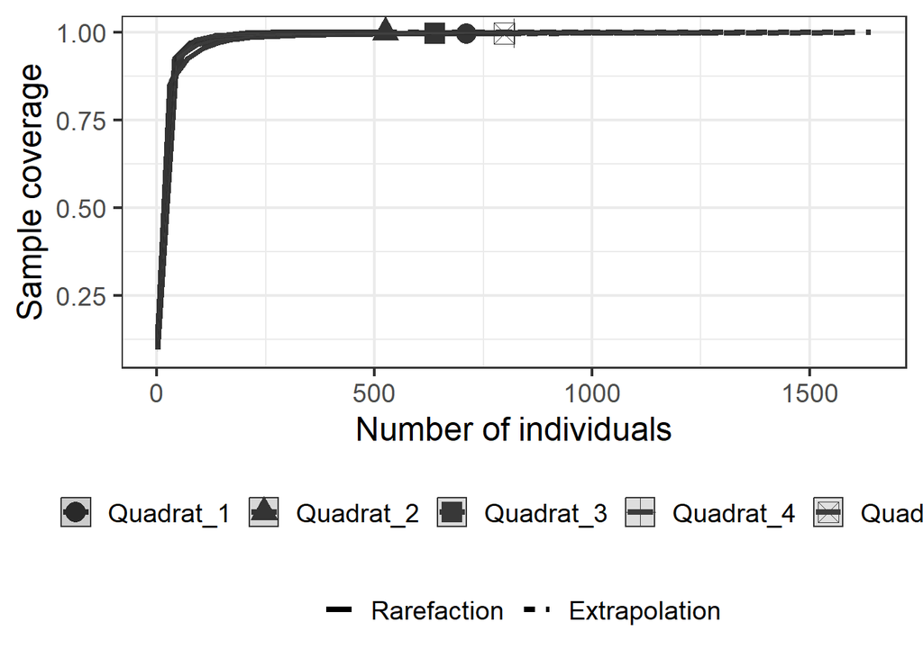

```r
Fallin_Data_Graph3 <- ggiNEXT(x = Fallin_Data, se=TRUE, type = 2,
                              facet.var="None", grey=TRUE)
Fallin_Data_Graph3
```

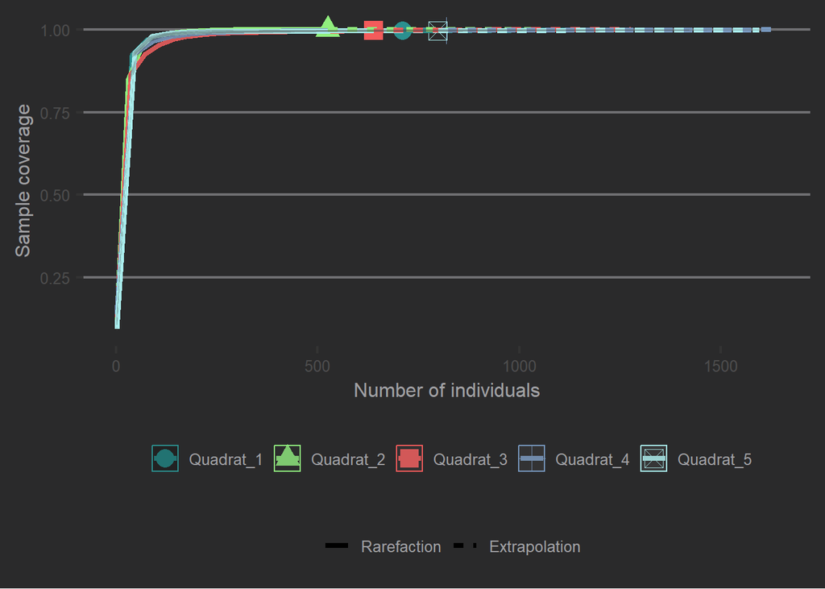

```r
Falling3 <- Fallin_Data_Graph3 + theme_hc(style = "darkunica") +
  scale_colour_hc("darkunica")
Falling3
```

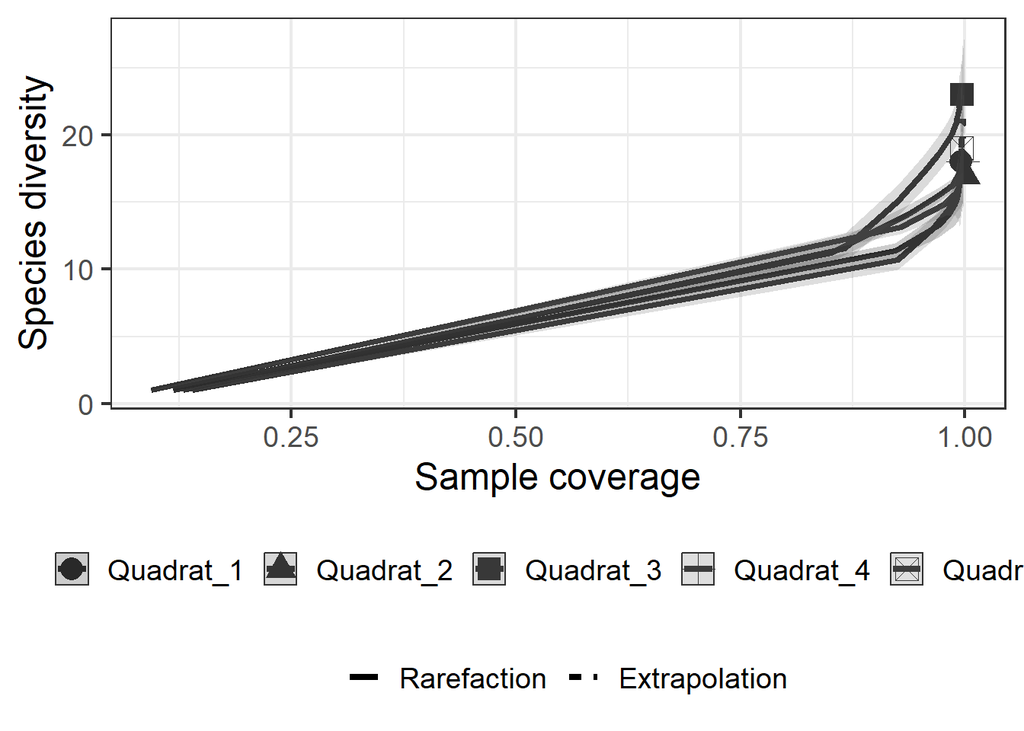

```r
Fallin_Data_Graph4 <- ggiNEXT(x = Fallin_Data, se=TRUE, type = 3,
                              facet.var="None", grey=TRUE)
Fallin_Data_Graph4
```

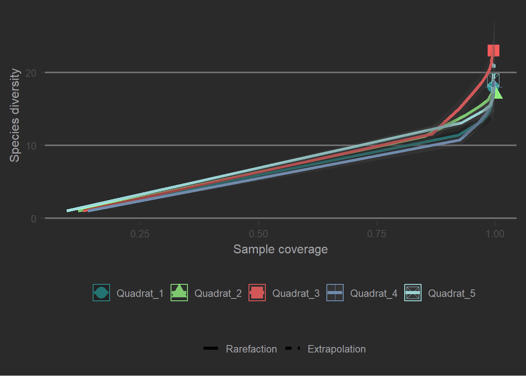

```r
Falling4 <- Fallin_Data_Graph4 + theme_hc(style = "darkunica") +
  scale_colour_hc("darkunica")
Falling4
```

##Addiewell Data##

##Loading the Addiewell data##

```r
urlfile3 <- 'https://raw.githubusercontent.com/Savannankvm/Biodiversity-analyses-for-six-study-sites/PhD-files/Addiewell_Abundance_Data.csv'

Addiewell_Nos <-read.csv(urlfile3)

print(Addiewell_Nos)
```

```
##     Quadrat.1 Quadrat.2 Quadrat.3 Quadrat.4 Quadrat.5
## 1           1         0         0         0        14
## 2           0         0         0         0         0
## 3           0         0         0         0         0
## 4           0         0         0         0         0
## 5           0         0         0         0         0
## 6           0         0         0         0         0
## 7           0         0         0         0         0
## 8           0         0         0         0        11
## 9           0         0         3         1         0
## 10          0         0        10         0         0
## 11          0         0         0         0         0
## 12          0         0         0         0         0
## 13          0         0         0         0         0
## 14          0         0         0         0         0
```

[output cut: 129 more lines]

#colSums to establish sample size for each of the quadrats.

```r
colSums(Addiewell_Nos)
```

```
## Quadrat.1 Quadrat.2 Quadrat.3 Quadrat.4 Quadrat.5
##       420       533       621       824       395
```

#Setting m to sample size for Quadrat 1. This will give me observed #qD value that will be most representative for Quadrat and Community. Will do the same #for the other communities below.

```r
m <- c(420)

Addiewell_Datam <- iNEXT(Addiewell_Nos, q=c(0), datatype= "abundance", size = m)

Addiewell_Datam
```

```
## Compare 5 assemblages with Hill number order q = 0.
## $class: iNEXT
##
## $DataInfo: basic data information
##   Assemblage   n S.obs     SC f1 f2 f3 f4 f5 f6 f7 f8 f9 f10
## 1  Quadrat.1 420    17 0.9953  2  0  1  1  2  0  0  2  0   4
## 2  Quadrat.2 533    12 0.9963  2  1  1  1  0  0  0  1  0   0
## 3  Quadrat.3 621    23 0.9936  4  1  2  2  1  0  0  0  0   3
## 4  Quadrat.4 824    17 1.0000  1  0  0  0  0  0  0  0  0   6
## 5  Quadrat.5 395    22 0.9874  5  1  0  2  0  0  0  1  1   4
##
## $iNextEst: diversity estimates with rarefied and extrapolated samples.
## $size_based (LCL and UCL are obtained for fixed size.)
##
##    Assemblage   m        Method Order.q       qD    qD.LCL   qD.UCL        SC
```

[output cut: 93 more lines]

```r
n <- c(533)

Addiewell_Datan <- iNEXT(Addiewell_Nos, q=c(0), datatype= "abundance", size = n)

Addiewell_Datan
```

```
## Compare 5 assemblages with Hill number order q = 0.
## $class: iNEXT
##
## $DataInfo: basic data information
##   Assemblage   n S.obs     SC f1 f2 f3 f4 f5 f6 f7 f8 f9 f10
## 1  Quadrat.1 420    17 0.9953  2  0  1  1  2  0  0  2  0   4
## 2  Quadrat.2 533    12 0.9963  2  1  1  1  0  0  0  1  0   0
## 3  Quadrat.3 621    23 0.9936  4  1  2  2  1  0  0  0  0   3
## 4  Quadrat.4 824    17 1.0000  1  0  0  0  0  0  0  0  0   6
## 5  Quadrat.5 395    22 0.9874  5  1  0  2  0  0  0  1  1   4
##
## $iNextEst: diversity estimates with rarefied and extrapolated samples.
## $size_based (LCL and UCL are obtained for fixed size.)
##
##    Assemblage   m        Method Order.q       qD    qD.LCL   qD.UCL        SC
```

[output cut: 93 more lines]

```r
o <- c(621)

Addiewell_Datao <- iNEXT(Addiewell_Nos, q=c(0), datatype= "abundance", size = o)

Addiewell_Datao
```

```
## Compare 5 assemblages with Hill number order q = 0.
## $class: iNEXT
##
## $DataInfo: basic data information
##   Assemblage   n S.obs     SC f1 f2 f3 f4 f5 f6 f7 f8 f9 f10
## 1  Quadrat.1 420    17 0.9953  2  0  1  1  2  0  0  2  0   4
## 2  Quadrat.2 533    12 0.9963  2  1  1  1  0  0  0  1  0   0
## 3  Quadrat.3 621    23 0.9936  4  1  2  2  1  0  0  0  0   3
## 4  Quadrat.4 824    17 1.0000  1  0  0  0  0  0  0  0  0   6
## 5  Quadrat.5 395    22 0.9874  5  1  0  2  0  0  0  1  1   4
##
## $iNextEst: diversity estimates with rarefied and extrapolated samples.
## $size_based (LCL and UCL are obtained for fixed size.)
##
##    Assemblage   m        Method Order.q       qD   qD.LCL   qD.UCL        SC
```

[output cut: 93 more lines]

```r
p <- c(824)

Addiewell_Datap <- iNEXT(Addiewell_Nos, q=c(0), datatype= "abundance", size = p)

Addiewell_Datap
```

```
## Compare 5 assemblages with Hill number order q = 0.
## $class: iNEXT
##
## $DataInfo: basic data information
##   Assemblage   n S.obs     SC f1 f2 f3 f4 f5 f6 f7 f8 f9 f10
## 1  Quadrat.1 420    17 0.9953  2  0  1  1  2  0  0  2  0   4
## 2  Quadrat.2 533    12 0.9963  2  1  1  1  0  0  0  1  0   0
## 3  Quadrat.3 621    23 0.9936  4  1  2  2  1  0  0  0  0   3
## 4  Quadrat.4 824    17 1.0000  1  0  0  0  0  0  0  0  0   6
## 5  Quadrat.5 395    22 0.9874  5  1  0  2  0  0  0  1  1   4
##
## $iNextEst: diversity estimates with rarefied and extrapolated samples.
## $size_based (LCL and UCL are obtained for fixed size.)
##
##    Assemblage   m        Method Order.q       qD    qD.LCL   qD.UCL        SC
```

[output cut: 94 more lines]

```r
q <- c(395)

Addiewell_Dataq <- iNEXT(Addiewell_Nos, q=c(0), datatype= "abundance", size = q)

Addiewell_Dataq
```

```
## Compare 5 assemblages with Hill number order q = 0.
## $class: iNEXT
##
## $DataInfo: basic data information
##   Assemblage   n S.obs     SC f1 f2 f3 f4 f5 f6 f7 f8 f9 f10
## 1  Quadrat.1 420    17 0.9953  2  0  1  1  2  0  0  2  0   4
## 2  Quadrat.2 533    12 0.9963  2  1  1  1  0  0  0  1  0   0
## 3  Quadrat.3 621    23 0.9936  4  1  2  2  1  0  0  0  0   3
## 4  Quadrat.4 824    17 1.0000  1  0  0  0  0  0  0  0  0   6
## 5  Quadrat.5 395    22 0.9874  5  1  0  2  0  0  0  1  1   4
##
## $iNextEst: diversity estimates with rarefied and extrapolated samples.
## $size_based (LCL and UCL are obtained for fixed size.)
##
##    Assemblage   m        Method Order.q       qD    qD.LCL   qD.UCL        SC
```

[output cut: 93 more lines]

#Now to run the analysis again without specificying the size, can do this for #looking at the other diversity indices

```r
Addiewell_Data <- iNEXT(Addiewell_Nos, q=c(0), datatype= "abundance")

print(Addiewell_Data)
```

```
## Compare 5 assemblages with Hill number order q = 0.
## $class: iNEXT
##
## $DataInfo: basic data information
##   Assemblage   n S.obs     SC f1 f2 f3 f4 f5 f6 f7 f8 f9 f10
## 1  Quadrat.1 420    17 0.9953  2  0  1  1  2  0  0  2  0   4
## 2  Quadrat.2 533    12 0.9963  2  1  1  1  0  0  0  1  0   0
## 3  Quadrat.3 621    23 0.9936  4  1  2  2  1  0  0  0  0   3
## 4  Quadrat.4 824    17 1.0000  1  0  0  0  0  0  0  0  0   6
## 5  Quadrat.5 395    22 0.9874  5  1  0  2  0  0  0  1  1   4
##
## $iNextEst: diversity estimates with rarefied and extrapolated samples.
## $size_based (LCL and UCL are obtained for fixed size.)
##
##     Assemblage    m        Method Order.q       qD    qD.LCL   qD.UCL        SC
```

[output cut: 144 more lines]

##Now to do further analyses for initial biodiversity indices for Addiewell, including sample coverage

```r
A1 <- diversity(Addiewell_Nos$Quadrat.1)

Addiewell2 <- estimateD(Addiewell_Nos, q = c(0,1,2), datatype = "abundance", base="coverage")
Addiewell2
```

```
##    Assemblage        m        Method Order.q        SC        qD    qD.LCL
## 1   Quadrat.1 226.2999   Rarefaction       0 0.9915304 15.889971 14.418400
## 2   Quadrat.1 226.2999   Rarefaction       1 0.9915304  7.197444  6.296685
## 3   Quadrat.1 226.2999   Rarefaction       2 0.9915304  4.754314  4.082784
## 4   Quadrat.2 254.0636   Rarefaction       0 0.9915304 10.457635  8.062079
## 5   Quadrat.2 254.0636   Rarefaction       1 0.9915304  5.858901  5.495032
## 6   Quadrat.2 254.0636   Rarefaction       2 0.9915304  4.970042  4.617688
## 7   Quadrat.3 444.1923   Rarefaction       0 0.9915304 21.720179 12.574855
## 8   Quadrat.3 444.1923   Rarefaction       1 0.9915304 10.315575  9.331317
## 9   Quadrat.3 444.1923   Rarefaction       2 0.9915304  7.272036  6.448958
## 10  Quadrat.4 186.9737   Rarefaction       0 0.9915304 15.770875 15.287802
## 11  Quadrat.4 186.9737   Rarefaction       1 0.9915304 10.826412 10.239085
## 12  Quadrat.4 186.9737   Rarefaction       2 0.9915304  9.057737  8.453411
## 13  Quadrat.5 790.0000 Extrapolation       0 0.9915304 26.117349 10.306162
## 14  Quadrat.5 790.0000 Extrapolation       1 0.9915304  9.459618  8.073684
```

[output cut: 17 more lines]

#Running vegan analyses for species evenness for Addiewell data#

```r
Aevenness1 <- A1/log(specnumber(Addiewell_Nos$Quadrat.1))

summary(Aevenness1)
```

```
##    Min. 1st Qu.  Median    Mean 3rd Qu.    Max.
##  0.7031  0.7031  0.7031  0.7031  0.7031  0.7031
```

```r
A2 <- diversity(Addiewell_Nos$Quadrat.2)

Aevenness2 <- A2/log(specnumber(Addiewell_Nos$Quadrat.2))

summary(Aevenness2)
```

```
##    Min. 1st Qu.  Median    Mean 3rd Qu.    Max.
##  0.7168  0.7168  0.7168  0.7168  0.7168  0.7168
```

```r
A3 <- diversity(Addiewell_Nos$Quadrat.3)

Aevenness3 <- A3/log(specnumber(Addiewell_Nos$Quadrat.3))

summary(Aevenness3)
```

```
##    Min. 1st Qu.  Median    Mean 3rd Qu.    Max.
##  0.7469  0.7469  0.7469  0.7469  0.7469  0.7469
```

```r
A4 <- diversity(Addiewell_Nos$Quadrat.4)

Aevenness4 <- A4/log(specnumber(Addiewell_Nos$Quadrat.4))

summary(Aevenness4)
```

```
##    Min. 1st Qu.  Median    Mean 3rd Qu.    Max.
##  0.8531  0.8531  0.8531  0.8531  0.8531  0.8531
```

```r
A5 <- diversity(Addiewell_Nos$Quadrat.5)

Aevenness5 <- A5/log(specnumber(Addiewell_Nos$Quadrat.5))

summary(Aevenness5)
```

```
##    Min. 1st Qu.  Median    Mean 3rd Qu.    Max.
##  0.7195  0.7195  0.7195  0.7195  0.7195  0.7195
```

#Now to create some graphs for better visualisation of the data, including species curves#

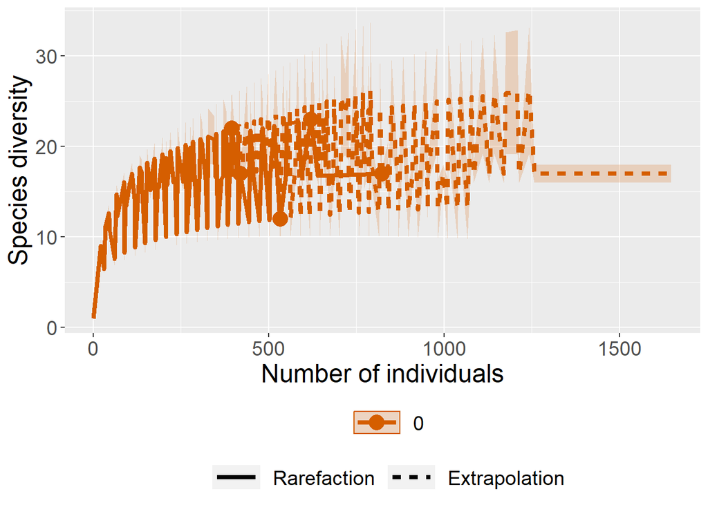

```r
Addiewell_Data_Graph1 <- ggiNEXT(x = Addiewell_Data, se=TRUE, color.var="Order.q")

Addiewell_Data_Graph1
```

```r
Addiewell_Data_Graph1.1 <- ggiNEXT(x = Addiewell_Data, se=TRUE,
                                   facet.var = "None", grey=TRUE)
Addiewell_Data_Graph1.1
```

[output not shown]

```r
Addiewell_Data_Graph2 <- ggiNEXT(x = Addiewell_Data, se=TRUE, type = 1,
                                 facet.var = "None", grey=TRUE)
Addiewell_Data_Graph2
```

[output not shown]

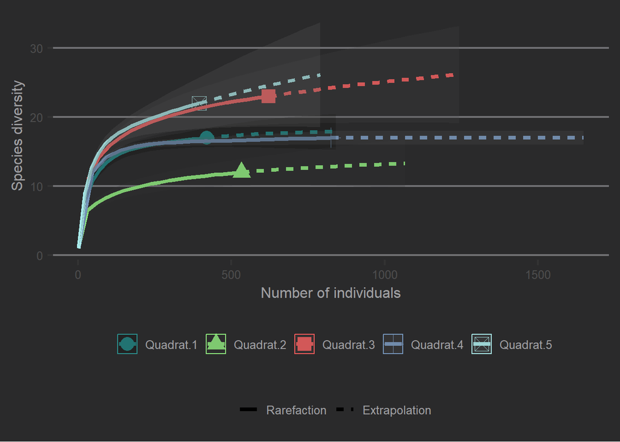

```r
Addiewellg2 <- Addiewell_Data_Graph2 + theme_hc(style = "darkunica") +
  scale_colour_hc("darkunica")
Addiewellg2
```

```r
Addiewell_Data_Graph2.1 <- ggiNEXT(x = Addiewell_Data, se=TRUE, type = 1,
                                   facet.var="None", grey=TRUE)
Addiewell_Data_Graph2.1
```

[output not shown]

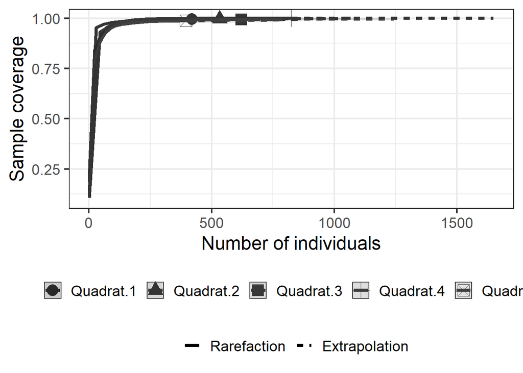

```r
Addiewell_Data_Graph3 <- ggiNEXT(x = Addiewell_Data, se=TRUE, type = 2,
                                 facet.var="None", grey = TRUE)
Addiewell_Data_Graph3
```

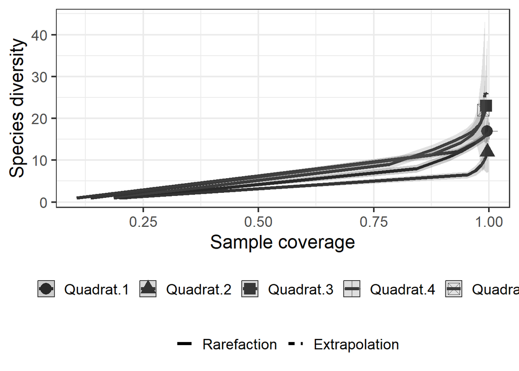

```r
Addiewell_Data_Graph4 <- ggiNEXT(x = Addiewell_Data, se=TRUE, type = 3,
                                 facet.var="None", grey = TRUE)
Addiewell_Data_Graph4
```

#Hodbarrow Data#

#Loading the Hodbarrow data#

```r
urlfile4 <- 'https://raw.githubusercontent.com/Savannankvm/Biodiversity-analyses-for-six-study-sites/PhD-files/Hodbarrow_Abundance_Data.csv'

Hodbarrow_Nos <-read.csv(urlfile4)

print(Hodbarrow_Nos)
```

```
##     Quadrat_1 Quadrat_2 Quadrat_3 Quadrat_4 Quadrat_5 Quadrat_6 Quadrat_7
## 1           0         0         0         0         0         0         0
## 2           0         0         0         0         0         0         0
## 3           0         0         0         0         0         0         0
## 4           0         0         0         0         0         0         0
## 5           0         0         0         0         0         0         0
## 6           0         0         0         7         0         0         0
## 7           0        70       189         0         0         0         0
## 8           0         0         0         0         0         0         0
## 9           0         0         0         0         0         0         0
## 10          0         0         0         0         0         0         0
## 11          0         0         0         0         0         0         0
## 12          0         0         1         0         0         0         0
## 13          0         0         0         0         0         0         0
## 14          0         0         0         0         0         0         0
```

[output cut: 129 more lines]

#colSums to establish sample size for each of the quadrats.

```r
colSums(Hodbarrow_Nos)
```

```
## Quadrat_1 Quadrat_2 Quadrat_3 Quadrat_4 Quadrat_5 Quadrat_6 Quadrat_7
##       213       396       617       577       433       106       216
```

#Setting m to sample size for Quadrat 1. This will give me observed #qD value that will be most representative for Quadrat and Community. Will do the same #for the other communities below.

```r
m <- c(213)

Hodbarrow_Datam <- iNEXT(Hodbarrow_Nos, q=c(0), datatype= "abundance", size = m)

Hodbarrow_Datam
```

```
## Compare 7 assemblages with Hill number order q = 0.
## $class: iNEXT
##
## $DataInfo: basic data information
##   Assemblage   n S.obs     SC f1 f2 f3 f4 f5 f6 f7 f8 f9 f10
## 1  Quadrat_1 213     6 1.0000  0  3  0  0  0  0  0  0  0   1
## 2  Quadrat_2 396     7 1.0000  0  1  0  1  1  0  0  0  0   0
## 3  Quadrat_3 617    10 0.9951  3  1  0  1  0  0  0  0  0   0
## 4  Quadrat_4 577    15 0.9965  2  1  1  1  1  0  1  0  0   1
## 5  Quadrat_5 433    18 0.9954  2  2  2  0  1  1  0  0  0   0
## 6  Quadrat_6 106     7 0.9909  1  2  0  0  0  1  1  0  0   1
## 7  Quadrat_7 216    14 0.9908  2  2  0  0  0  1  1  0  0   2
##
## $iNextEst: diversity estimates with rarefied and extrapolated samples.
## $size_based (LCL and UCL are obtained for fixed size.)
```

[output cut: 130 more lines]

```r
n <- c(396)

Hodbarrow_Datan <- iNEXT(Hodbarrow_Nos, q=c(0), datatype= "abundance", size = n)

Hodbarrow_Datan
```

```
## Compare 7 assemblages with Hill number order q = 0.
## $class: iNEXT
##
## $DataInfo: basic data information
##   Assemblage   n S.obs     SC f1 f2 f3 f4 f5 f6 f7 f8 f9 f10
## 1  Quadrat_1 213     6 1.0000  0  3  0  0  0  0  0  0  0   1
## 2  Quadrat_2 396     7 1.0000  0  1  0  1  1  0  0  0  0   0
## 3  Quadrat_3 617    10 0.9951  3  1  0  1  0  0  0  0  0   0
## 4  Quadrat_4 577    15 0.9965  2  1  1  1  1  0  1  0  0   1
## 5  Quadrat_5 433    18 0.9954  2  2  2  0  1  1  0  0  0   0
## 6  Quadrat_6 106     7 0.9909  1  2  0  0  0  1  1  0  0   1
## 7  Quadrat_7 216    14 0.9908  2  2  0  0  0  1  1  0  0   2
##
## $iNextEst: diversity estimates with rarefied and extrapolated samples.
## $size_based (LCL and UCL are obtained for fixed size.)
```

[output cut: 129 more lines]

```r
o <- c(617)

Hodbarrow_Datao <- iNEXT(Hodbarrow_Nos, q=c(0), datatype= "abundance", size = o)

Hodbarrow_Datao
```

```
## Compare 7 assemblages with Hill number order q = 0.
## $class: iNEXT
##
## $DataInfo: basic data information
##   Assemblage   n S.obs     SC f1 f2 f3 f4 f5 f6 f7 f8 f9 f10
## 1  Quadrat_1 213     6 1.0000  0  3  0  0  0  0  0  0  0   1
## 2  Quadrat_2 396     7 1.0000  0  1  0  1  1  0  0  0  0   0
## 3  Quadrat_3 617    10 0.9951  3  1  0  1  0  0  0  0  0   0
## 4  Quadrat_4 577    15 0.9965  2  1  1  1  1  0  1  0  0   1
## 5  Quadrat_5 433    18 0.9954  2  2  2  0  1  1  0  0  0   0
## 6  Quadrat_6 106     7 0.9909  1  2  0  0  0  1  1  0  0   1
## 7  Quadrat_7 216    14 0.9908  2  2  0  0  0  1  1  0  0   2
##
## $iNextEst: diversity estimates with rarefied and extrapolated samples.
## $size_based (LCL and UCL are obtained for fixed size.)
```

[output cut: 126 more lines]

```r
p <- c(577)

Hodbarrow_Datap <- iNEXT(Hodbarrow_Nos, q=c(0), datatype= "abundance", size = p)

Hodbarrow_Datap
```

```
## Compare 7 assemblages with Hill number order q = 0.
## $class: iNEXT
##
## $DataInfo: basic data information
##   Assemblage   n S.obs     SC f1 f2 f3 f4 f5 f6 f7 f8 f9 f10
## 1  Quadrat_1 213     6 1.0000  0  3  0  0  0  0  0  0  0   1
## 2  Quadrat_2 396     7 1.0000  0  1  0  1  1  0  0  0  0   0
## 3  Quadrat_3 617    10 0.9951  3  1  0  1  0  0  0  0  0   0
## 4  Quadrat_4 577    15 0.9965  2  1  1  1  1  0  1  0  0   1
## 5  Quadrat_5 433    18 0.9954  2  2  2  0  1  1  0  0  0   0
## 6  Quadrat_6 106     7 0.9909  1  2  0  0  0  1  1  0  0   1
## 7  Quadrat_7 216    14 0.9908  2  2  0  0  0  1  1  0  0   2
##
## $iNextEst: diversity estimates with rarefied and extrapolated samples.
## $size_based (LCL and UCL are obtained for fixed size.)
```

[output cut: 126 more lines]

```r
q <- c(433)

Hodbarrow_Dataq <- iNEXT(Hodbarrow_Nos, q=c(0), datatype= "abundance", size = q)

Hodbarrow_Dataq
```

```
## Compare 7 assemblages with Hill number order q = 0.
## $class: iNEXT
##
## $DataInfo: basic data information
##   Assemblage   n S.obs     SC f1 f2 f3 f4 f5 f6 f7 f8 f9 f10
## 1  Quadrat_1 213     6 1.0000  0  3  0  0  0  0  0  0  0   1
## 2  Quadrat_2 396     7 1.0000  0  1  0  1  1  0  0  0  0   0
## 3  Quadrat_3 617    10 0.9951  3  1  0  1  0  0  0  0  0   0
## 4  Quadrat_4 577    15 0.9965  2  1  1  1  1  0  1  0  0   1
## 5  Quadrat_5 433    18 0.9954  2  2  2  0  1  1  0  0  0   0
## 6  Quadrat_6 106     7 0.9909  1  2  0  0  0  1  1  0  0   1
## 7  Quadrat_7 216    14 0.9908  2  2  0  0  0  1  1  0  0   2
##
## $iNextEst: diversity estimates with rarefied and extrapolated samples.
## $size_based (LCL and UCL are obtained for fixed size.)
```

[output cut: 126 more lines]

```r
r <- c(106)

Hodbarrow_Datar <- iNEXT(Hodbarrow_Nos, q=c(0), datatype= "abundance", size = r)

Hodbarrow_Datar
```

```
## Compare 7 assemblages with Hill number order q = 0.
## $class: iNEXT
##
## $DataInfo: basic data information
##   Assemblage   n S.obs     SC f1 f2 f3 f4 f5 f6 f7 f8 f9 f10
## 1  Quadrat_1 213     6 1.0000  0  3  0  0  0  0  0  0  0   1
## 2  Quadrat_2 396     7 1.0000  0  1  0  1  1  0  0  0  0   0
## 3  Quadrat_3 617    10 0.9951  3  1  0  1  0  0  0  0  0   0
## 4  Quadrat_4 577    15 0.9965  2  1  1  1  1  0  1  0  0   1
## 5  Quadrat_5 433    18 0.9954  2  2  2  0  1  1  0  0  0   0
## 6  Quadrat_6 106     7 0.9909  1  2  0  0  0  1  1  0  0   1
## 7  Quadrat_7 216    14 0.9908  2  2  0  0  0  1  1  0  0   2
##
## $iNextEst: diversity estimates with rarefied and extrapolated samples.
## $size_based (LCL and UCL are obtained for fixed size.)
```

[output cut: 128 more lines]

```r
s <- c(216)

Hodbarrow_Datas <- iNEXT(Hodbarrow_Nos, q=c(0), datatype= "abundance", size = s)

Hodbarrow_Datas
```

```
## Compare 7 assemblages with Hill number order q = 0.
## $class: iNEXT
##
## $DataInfo: basic data information
##   Assemblage   n S.obs     SC f1 f2 f3 f4 f5 f6 f7 f8 f9 f10
## 1  Quadrat_1 213     6 1.0000  0  3  0  0  0  0  0  0  0   1
## 2  Quadrat_2 396     7 1.0000  0  1  0  1  1  0  0  0  0   0
## 3  Quadrat_3 617    10 0.9951  3  1  0  1  0  0  0  0  0   0
## 4  Quadrat_4 577    15 0.9965  2  1  1  1  1  0  1  0  0   1
## 5  Quadrat_5 433    18 0.9954  2  2  2  0  1  1  0  0  0   0
## 6  Quadrat_6 106     7 0.9909  1  2  0  0  0  1  1  0  0   1
## 7  Quadrat_7 216    14 0.9908  2  2  0  0  0  1  1  0  0   2
##
## $iNextEst: diversity estimates with rarefied and extrapolated samples.
## $size_based (LCL and UCL are obtained for fixed size.)
```

[output cut: 127 more lines]

#Now to run the analysis again without specificying the size, can do this for #looking at the other diversity indices

```r
Hodbarrow_Data <- iNEXT(Hodbarrow_Nos, q=c(0), datatype= "abundance")

print(Hodbarrow_Data)
```

```
## Compare 7 assemblages with Hill number order q = 0.
## $class: iNEXT
##
## $DataInfo: basic data information
##   Assemblage   n S.obs     SC f1 f2 f3 f4 f5 f6 f7 f8 f9 f10
## 1  Quadrat_1 213     6 1.0000  0  3  0  0  0  0  0  0  0   1
## 2  Quadrat_2 396     7 1.0000  0  1  0  1  1  0  0  0  0   0
## 3  Quadrat_3 617    10 0.9951  3  1  0  1  0  0  0  0  0   0
## 4  Quadrat_4 577    15 0.9965  2  1  1  1  1  0  1  0  0   1
## 5  Quadrat_5 433    18 0.9954  2  2  2  0  1  1  0  0  0   0
## 6  Quadrat_6 106     7 0.9909  1  2  0  0  0  1  1  0  0   1
## 7  Quadrat_7 216    14 0.9908  2  2  0  0  0  1  1  0  0   2
##
## $iNextEst: diversity estimates with rarefied and extrapolated samples.
## $size_based (LCL and UCL are obtained for fixed size.)
```

[output cut: 198 more lines]

#Running further analyses to obtain additional biodiversity indices, including sample coverage#

```r
Hodbarrow2 <- estimateD(Hodbarrow_Nos, q = c(0,1,2), datatype = "abundance", base="coverage")
Hodbarrow2
```

```
##    Assemblage         m        Method Order.q        SC        qD    qD.LCL
## 1   Quadrat_1  193.2463   Rarefaction       0 0.9975081  5.975376  4.385207
## 2   Quadrat_1  193.2463   Rarefaction       1 0.9975081  2.349177  2.062580
## 3   Quadrat_1  193.2463   Rarefaction       2 0.9975081  1.827118  1.613516
## 4   Quadrat_2  252.7154   Rarefaction       0 0.9975081  6.847050  6.016434
## 5   Quadrat_2  252.7154   Rarefaction       1 0.9975081  3.526803  3.210834
## 6   Quadrat_2  252.7154   Rarefaction       2 0.9975081  2.731753  2.425556
## 7   Quadrat_3 1234.0000 Extrapolation       0 0.9975081 12.187737  4.339551
## 8   Quadrat_3 1234.0000 Extrapolation       1 0.9975081  4.323037  4.053776
## 9   Quadrat_3 1234.0000 Extrapolation       2 0.9975081  3.497420  3.255940
## 10  Quadrat_4  766.2629 Extrapolation       0 0.9975081 15.558731 11.496982
## 11  Quadrat_4  766.2629 Extrapolation       1 0.9975081  7.270478  6.717240
## 12  Quadrat_4  766.2629 Extrapolation       2 0.9975081  5.778112  5.324217
## 13  Quadrat_5  565.6096 Extrapolation       0 0.9975081 18.456957 11.918367
## 14  Quadrat_5  565.6096 Extrapolation       1 0.9975081 11.157573 10.407259
```

[output cut: 29 more lines]

#Running vegan analyses for Hodbarrow, to obtain species evenness indices

```r
R1 <- diversity(Hodbarrow_Nos$Quadrat_1)

Revenness1 <- R1/log(specnumber(Hodbarrow_Nos$Quadrat_1))

summary(Revenness1)
```

```
##    Min. 1st Qu.  Median    Mean 3rd Qu.    Max.
##  0.4775  0.4775  0.4775  0.4775  0.4775  0.4775
```

```r
R2 <- diversity(Hodbarrow_Nos$Quadrat_2)

Revenness2 <- R2/log(specnumber(Hodbarrow_Nos$Quadrat_2))

summary(Revenness2)
```

```
##    Min. 1st Qu.  Median    Mean 3rd Qu.    Max.
##  0.6502  0.6502  0.6502  0.6502  0.6502  0.6502
```

```r
R3 <- diversity(Hodbarrow_Nos$Quadrat_3)

Revenness3 <- R3/log(specnumber(Hodbarrow_Nos$Quadrat_3))

summary(Revenness3)
```

```
##    Min. 1st Qu.  Median    Mean 3rd Qu.    Max.
##  0.6329  0.6329  0.6329  0.6329  0.6329  0.6329
```

```r
R4 <- diversity(Hodbarrow_Nos$Quadrat_4)

Revenness4 <- R4/log(specnumber(Hodbarrow_Nos$Quadrat_4))

summary(Revenness4)
```

```
##    Min. 1st Qu.  Median    Mean 3rd Qu.    Max.
##  0.7311  0.7311  0.7311  0.7311  0.7311  0.7311
```

```r
R5 <- diversity(Hodbarrow_Nos$Quadrat_5)

Revenness5 <- R5/log(specnumber(Hodbarrow_Nos$Quadrat_5))

summary(Revenness5)
```

```
##    Min. 1st Qu.  Median    Mean 3rd Qu.    Max.
##  0.8324  0.8324  0.8324  0.8324  0.8324  0.8324
```

```r
R6 <- diversity(Hodbarrow_Nos$Quadrat_6)

Revenness6 <- R6/log(specnumber(Hodbarrow_Nos$Quadrat_6))

summary(Revenness6)
```

```
##    Min. 1st Qu.  Median    Mean 3rd Qu.    Max.
##  0.5058  0.5058  0.5058  0.5058  0.5058  0.5058
```

```r
R7 <- diversity(Hodbarrow_Nos$Quadrat_7)

Revenness7 <- R7/log(specnumber(Hodbarrow_Nos$Quadrat_7))

summary(Revenness7)
```

```
##    Min. 1st Qu.  Median    Mean 3rd Qu.    Max.
##   0.847   0.847   0.847   0.847   0.847   0.847
```

#Now for some data visualisation for the Hodbarrow data, including species curves graphs#

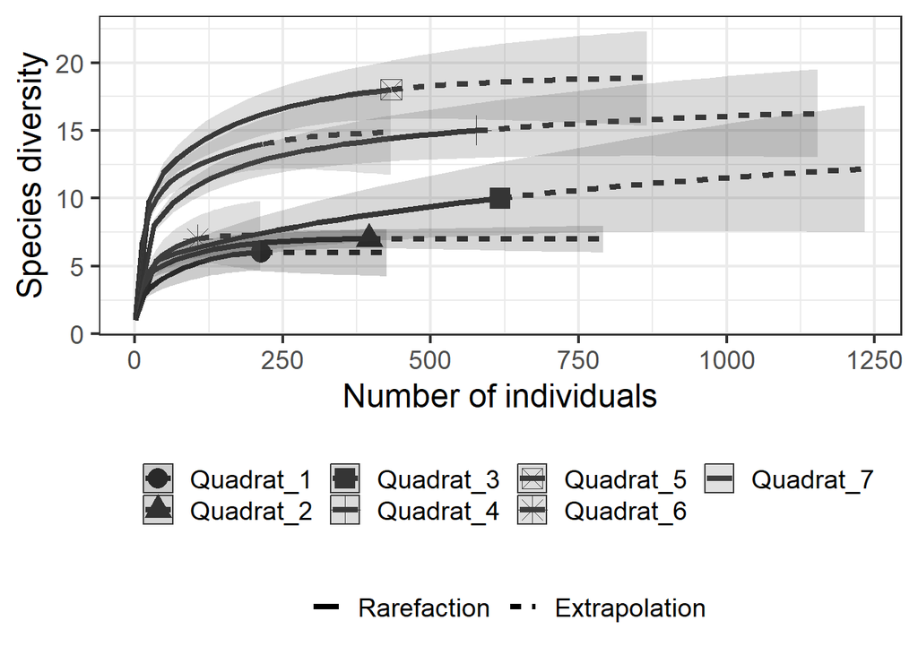

```r
Hodbarrow_Data_Graph1 <- ggiNEXT(x = Hodbarrow_Data, se=TRUE,
                                 facet.var= "None", grey=TRUE)
Hodbarrow_Data_Graph1
```

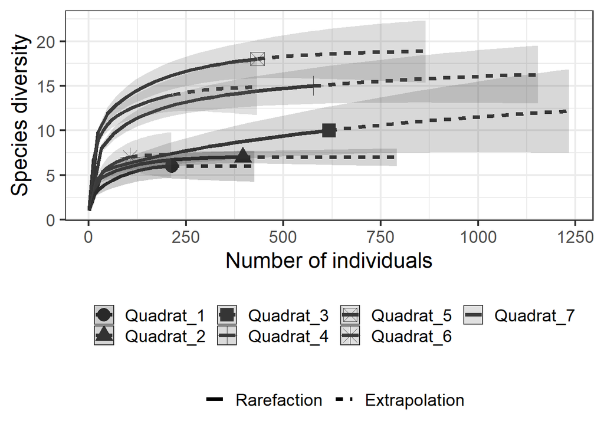

```r
Hodbarrow_Data_Graph2 <- ggiNEXT(x = Hodbarrow_Data, se=TRUE, type = 1,
                                 facet.var= "None", grey=TRUE)
Hodbarrow_Data_Graph2
```

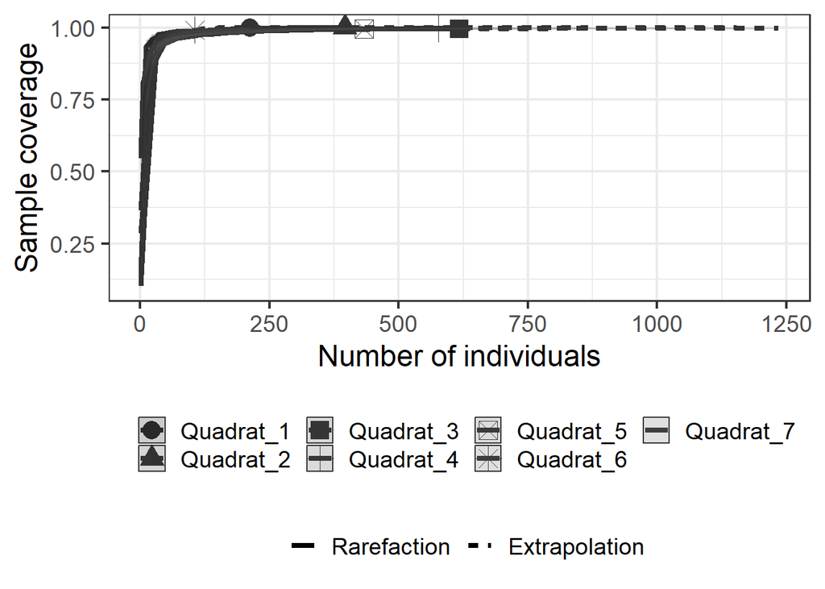

```r
Hodbarrow_Data_Graph3 <- ggiNEXT(x = Hodbarrow_Data, se=TRUE, type = 2,
                                 facet.var= "None", grey=TRUE)
Hodbarrow_Data_Graph3
```

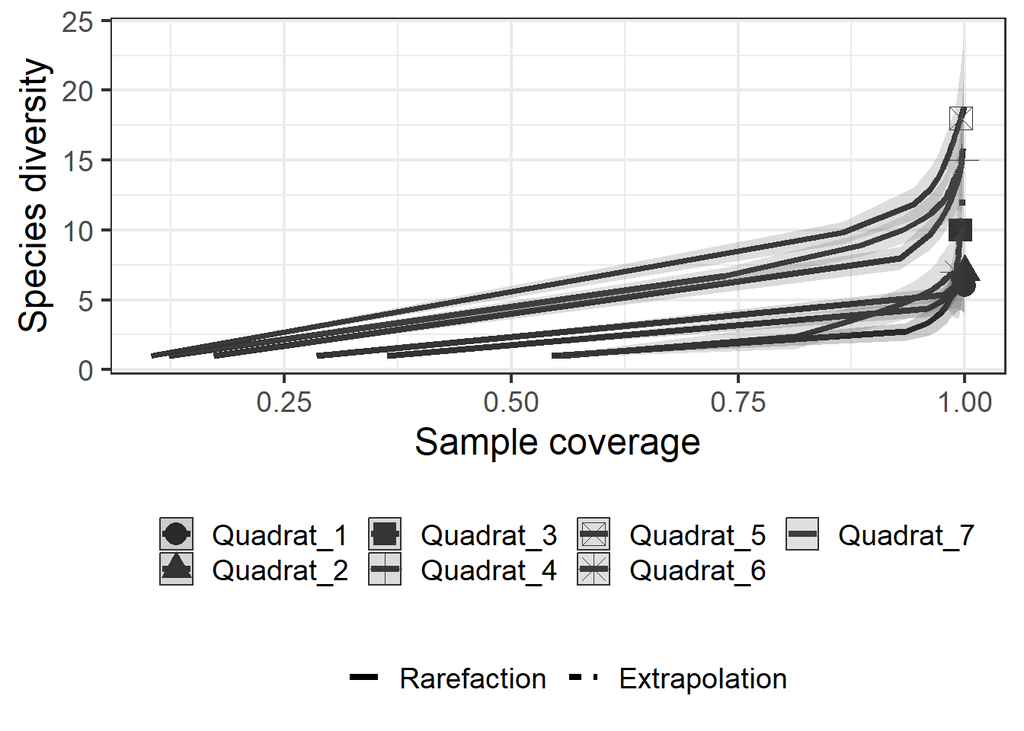

```r
Hodbarrow_Data_Graph4 <- ggiNEXT(x = Hodbarrow_Data, se=TRUE, type = 3,
                                 facet.var= "None", grey=TRUE)
Hodbarrow_Data_Graph4
```

#Warton#

#Loading the Warton data

```r
urlfile5 <- 'https://raw.githubusercontent.com/Savannankvm/Biodiversity-analyses-for-six-study-sites/PhD-files/Warton_Abundance_Data.csv'

Warton_Nos <-read.csv(urlfile5)

print(Warton_Nos)
```

```
##     Quadrat_1 Quadrat_2 Quadrat_3 Quadrat_4 Quadrat_5 Quadrat_6 Quadrat_7
## 1           0         0         0         0         0         0         0
## 2           0         0         0         0         0         0         0
## 3           0         0         0         0         0         0         0
## 4           0         0         0         0         0        27         0
## 5           0         0         0         0         0         0         0
## 6           0         0         0         0         0         0         0
## 7           0         0         0         0         0         0         0
## 8           0         0         0         0         0         0         0
## 9           1         0         0         0         0         0         0
## 10          0         0         0         0         0         0         0
## 11          0         0         0         0         0        11         0
## 12          0         0        11         0         0        10         0
## 13          0         0         0         0         0         0         0
## 14          0         0         0         0         0         0         0
```

[output cut: 273 more lines]

#colSums to establish sample size for each of the quadrats.

```r
colSums(Warton_Nos)
```

```
## Quadrat_1 Quadrat_2 Quadrat_3 Quadrat_4 Quadrat_5 Quadrat_6 Quadrat_7 Quadrat_8
##       795       568       552       322       517       206       319       343
```

#Setting m to sample size for Quadrat 1. This will give me observed #qD value that will be most representative for Quadrat and Community. Will do the same #for the other communities below.

```r
m <- c(795)

Warton_Datam <- iNEXT(Warton_Nos, q=c(0), datatype= "abundance", size = m)

Warton_Datam
```

```
## Compare 8 assemblages with Hill number order q = 0.
## $class: iNEXT
##
## $DataInfo: basic data information
##   Assemblage   n S.obs     SC f1 f2 f3 f4 f5 f6 f7 f8 f9 f10
## 1  Quadrat_1 795    14 0.9962  3  0  0  0  1  0  0  0  0   0
## 2  Quadrat_2 568     7 0.9965  2  0  0  0  1  0  1  0  0   0
## 3  Quadrat_3 552    12 1.0000  0  1  1  1  1  0  0  1  0   0
## 4  Quadrat_4 322    10 0.9969  1  1  1  0  0  0  0  0  0   0
## 5  Quadrat_5 517    12 0.9961  2  1  0  0  0  1  1  0  0   0
## 6  Quadrat_6 206    13 0.9952  1  1  0  1  1  0  0  0  0   3
## 7  Quadrat_7 319     7 1.0000  1  0  1  0  0  0  0  0  0   0
## 8  Quadrat_8 343     9 1.0000  0  0  0  0  0  0  0  1  0   0
##
## $iNextEst: diversity estimates with rarefied and extrapolated samples.
```

[output cut: 143 more lines]

```r
n <- c(568)

Warton_Datan <- iNEXT(Warton_Nos, q=c(0), datatype= "abundance", size = n)

Warton_Datan
```

```
## Compare 8 assemblages with Hill number order q = 0.
## $class: iNEXT
##
## $DataInfo: basic data information
##   Assemblage   n S.obs     SC f1 f2 f3 f4 f5 f6 f7 f8 f9 f10
## 1  Quadrat_1 795    14 0.9962  3  0  0  0  1  0  0  0  0   0
## 2  Quadrat_2 568     7 0.9965  2  0  0  0  1  0  1  0  0   0
## 3  Quadrat_3 552    12 1.0000  0  1  1  1  1  0  0  1  0   0
## 4  Quadrat_4 322    10 0.9969  1  1  1  0  0  0  0  0  0   0
## 5  Quadrat_5 517    12 0.9961  2  1  0  0  0  1  1  0  0   0
## 6  Quadrat_6 206    13 0.9952  1  1  0  1  1  0  0  0  0   3
## 7  Quadrat_7 319     7 1.0000  1  0  1  0  0  0  0  0  0   0
## 8  Quadrat_8 343     9 1.0000  0  0  0  0  0  0  0  1  0   0
##
## $iNextEst: diversity estimates with rarefied and extrapolated samples.
```

[output cut: 143 more lines]

```r
o <- c(552)

Warton_Datao <- iNEXT(Warton_Nos, q=c(0), datatype= "abundance", size = o)

Warton_Datao
```

```
## Compare 8 assemblages with Hill number order q = 0.
## $class: iNEXT
##
## $DataInfo: basic data information
##   Assemblage   n S.obs     SC f1 f2 f3 f4 f5 f6 f7 f8 f9 f10
## 1  Quadrat_1 795    14 0.9962  3  0  0  0  1  0  0  0  0   0
## 2  Quadrat_2 568     7 0.9965  2  0  0  0  1  0  1  0  0   0
## 3  Quadrat_3 552    12 1.0000  0  1  1  1  1  0  0  1  0   0
## 4  Quadrat_4 322    10 0.9969  1  1  1  0  0  0  0  0  0   0
## 5  Quadrat_5 517    12 0.9961  2  1  0  0  0  1  1  0  0   0
## 6  Quadrat_6 206    13 0.9952  1  1  0  1  1  0  0  0  0   3
## 7  Quadrat_7 319     7 1.0000  1  0  1  0  0  0  0  0  0   0
## 8  Quadrat_8 343     9 1.0000  0  0  0  0  0  0  0  1  0   0
##
## $iNextEst: diversity estimates with rarefied and extrapolated samples.
```

[output cut: 146 more lines]

```r
p <- c(322)

Warton_Datap <- iNEXT(Warton_Nos, q=c(0), datatype= "abundance", size = p)

Warton_Datap
```

```
## Compare 8 assemblages with Hill number order q = 0.
## $class: iNEXT
##
## $DataInfo: basic data information
##   Assemblage   n S.obs     SC f1 f2 f3 f4 f5 f6 f7 f8 f9 f10
## 1  Quadrat_1 795    14 0.9962  3  0  0  0  1  0  0  0  0   0
## 2  Quadrat_2 568     7 0.9965  2  0  0  0  1  0  1  0  0   0
## 3  Quadrat_3 552    12 1.0000  0  1  1  1  1  0  0  1  0   0
## 4  Quadrat_4 322    10 0.9969  1  1  1  0  0  0  0  0  0   0
## 5  Quadrat_5 517    12 0.9961  2  1  0  0  0  1  1  0  0   0
## 6  Quadrat_6 206    13 0.9952  1  1  0  1  1  0  0  0  0   3
## 7  Quadrat_7 319     7 1.0000  1  0  1  0  0  0  0  0  0   0
## 8  Quadrat_8 343     9 1.0000  0  0  0  0  0  0  0  1  0   0
##
## $iNextEst: diversity estimates with rarefied and extrapolated samples.
```

[output cut: 145 more lines]

```r
q <- c(517)

Warton_Dataq <- iNEXT(Warton_Nos, q=c(0), datatype= "abundance", size = q)

Warton_Dataq
```

```
## Compare 8 assemblages with Hill number order q = 0.
## $class: iNEXT
##
## $DataInfo: basic data information
##   Assemblage   n S.obs     SC f1 f2 f3 f4 f5 f6 f7 f8 f9 f10
## 1  Quadrat_1 795    14 0.9962  3  0  0  0  1  0  0  0  0   0
## 2  Quadrat_2 568     7 0.9965  2  0  0  0  1  0  1  0  0   0
## 3  Quadrat_3 552    12 1.0000  0  1  1  1  1  0  0  1  0   0
## 4  Quadrat_4 322    10 0.9969  1  1  1  0  0  0  0  0  0   0
## 5  Quadrat_5 517    12 0.9961  2  1  0  0  0  1  1  0  0   0
## 6  Quadrat_6 206    13 0.9952  1  1  0  1  1  0  0  0  0   3
## 7  Quadrat_7 319     7 1.0000  1  0  1  0  0  0  0  0  0   0
## 8  Quadrat_8 343     9 1.0000  0  0  0  0  0  0  0  1  0   0
##
## $iNextEst: diversity estimates with rarefied and extrapolated samples.
```

[output cut: 144 more lines]

```r
r <- c(206)

Warton_Datar <- iNEXT(Warton_Nos, q=c(0), datatype= "abundance", size = r)

Warton_Datar
```

```
## Compare 8 assemblages with Hill number order q = 0.
## $class: iNEXT
##
## $DataInfo: basic data information
##   Assemblage   n S.obs     SC f1 f2 f3 f4 f5 f6 f7 f8 f9 f10
## 1  Quadrat_1 795    14 0.9962  3  0  0  0  1  0  0  0  0   0
## 2  Quadrat_2 568     7 0.9965  2  0  0  0  1  0  1  0  0   0
## 3  Quadrat_3 552    12 1.0000  0  1  1  1  1  0  0  1  0   0
## 4  Quadrat_4 322    10 0.9969  1  1  1  0  0  0  0  0  0   0
## 5  Quadrat_5 517    12 0.9961  2  1  0  0  0  1  1  0  0   0
## 6  Quadrat_6 206    13 0.9952  1  1  0  1  1  0  0  0  0   3
## 7  Quadrat_7 319     7 1.0000  1  0  1  0  0  0  0  0  0   0
## 8  Quadrat_8 343     9 1.0000  0  0  0  0  0  0  0  1  0   0
##
## $iNextEst: diversity estimates with rarefied and extrapolated samples.
```

[output cut: 146 more lines]

```r
s <- c(319)

Warton_Datas <- iNEXT(Warton_Nos, q=c(0), datatype= "abundance", size = s)

Warton_Datas
```

```
## Compare 8 assemblages with Hill number order q = 0.
## $class: iNEXT
##
## $DataInfo: basic data information
##   Assemblage   n S.obs     SC f1 f2 f3 f4 f5 f6 f7 f8 f9 f10
## 1  Quadrat_1 795    14 0.9962  3  0  0  0  1  0  0  0  0   0
## 2  Quadrat_2 568     7 0.9965  2  0  0  0  1  0  1  0  0   0
## 3  Quadrat_3 552    12 1.0000  0  1  1  1  1  0  0  1  0   0
## 4  Quadrat_4 322    10 0.9969  1  1  1  0  0  0  0  0  0   0
## 5  Quadrat_5 517    12 0.9961  2  1  0  0  0  1  1  0  0   0
## 6  Quadrat_6 206    13 0.9952  1  1  0  1  1  0  0  0  0   3
## 7  Quadrat_7 319     7 1.0000  1  0  1  0  0  0  0  0  0   0
## 8  Quadrat_8 343     9 1.0000  0  0  0  0  0  0  0  1  0   0
##
## $iNextEst: diversity estimates with rarefied and extrapolated samples.
```

[output cut: 147 more lines]

```r
t <- c(343)

Warton_Datat <- iNEXT(Warton_Nos, q=c(0), datatype= "abundance", size = t)

Warton_Datat
```

```
## Compare 8 assemblages with Hill number order q = 0.
## $class: iNEXT
##
## $DataInfo: basic data information
##   Assemblage   n S.obs     SC f1 f2 f3 f4 f5 f6 f7 f8 f9 f10
## 1  Quadrat_1 795    14 0.9962  3  0  0  0  1  0  0  0  0   0
## 2  Quadrat_2 568     7 0.9965  2  0  0  0  1  0  1  0  0   0
## 3  Quadrat_3 552    12 1.0000  0  1  1  1  1  0  0  1  0   0
## 4  Quadrat_4 322    10 0.9969  1  1  1  0  0  0  0  0  0   0
## 5  Quadrat_5 517    12 0.9961  2  1  0  0  0  1  1  0  0   0
## 6  Quadrat_6 206    13 0.9952  1  1  0  1  1  0  0  0  0   3
## 7  Quadrat_7 319     7 1.0000  1  0  1  0  0  0  0  0  0   0
## 8  Quadrat_8 343     9 1.0000  0  0  0  0  0  0  0  1  0   0
##
## $iNextEst: diversity estimates with rarefied and extrapolated samples.
```

[output cut: 147 more lines]

#Now to run the analysis again without specificying the size, can do this for #looking at the other diversity indices

```r
Warton_Data <- iNEXT(Warton_Nos, q=c(0), datatype= "abundance")

print(Warton_Data)
```

```
## Compare 8 assemblages with Hill number order q = 0.
## $class: iNEXT
##
## $DataInfo: basic data information
##   Assemblage   n S.obs     SC f1 f2 f3 f4 f5 f6 f7 f8 f9 f10
## 1  Quadrat_1 795    14 0.9962  3  0  0  0  1  0  0  0  0   0
## 2  Quadrat_2 568     7 0.9965  2  0  0  0  1  0  1  0  0   0
## 3  Quadrat_3 552    12 1.0000  0  1  1  1  1  0  0  1  0   0
## 4  Quadrat_4 322    10 0.9969  1  1  1  0  0  0  0  0  0   0
## 5  Quadrat_5 517    12 0.9961  2  1  0  0  0  1  1  0  0   0
## 6  Quadrat_6 206    13 0.9952  1  1  0  1  1  0  0  0  0   3
## 7  Quadrat_7 319     7 1.0000  1  0  1  0  0  0  0  0  0   0
## 8  Quadrat_8 343     9 1.0000  0  0  0  0  0  0  0  1  0   0
##
## $iNextEst: diversity estimates with rarefied and extrapolated samples.
```

[output cut: 225 more lines]

```r
summary(Warton_Data)
```

```
##          Length Class      Mode
## DataInfo 14     data.frame list
## iNextEst  2     -none-     list
## AsyEst    7     data.frame list
```

#Now to obtain additional biodiversity indices for the Warton data, including sample coverage#

```r
W1 <- diversity(Warton_Nos$Quadrat_1)

Warton2 <- estimateD(Warton_Nos, q = c(0,1,2), datatype = "abundance", base="coverage")
Warton2
```

```
##    Assemblage         m        Method Order.q        SC        qD    qD.LCL
## 1   Quadrat_1 1571.0768 Extrapolation       0 0.9985810 15.868118 13.278652
## 2   Quadrat_1 1571.0768 Extrapolation       1 0.9985810  7.104569  6.672982
## 3   Quadrat_1 1571.0768 Extrapolation       2 0.9985810  5.110373  4.695801
## 4   Quadrat_2  825.1063 Extrapolation       0 0.9985810  7.594533  6.474955
## 5   Quadrat_2  825.1063 Extrapolation       1 0.9985810  3.140309  2.948680
## 6   Quadrat_2  825.1063 Extrapolation       2 0.9985810  2.729852  2.539643
## 7   Quadrat_3  411.3288   Rarefaction       0 0.9985810 11.913994 10.383177
## 8   Quadrat_3  411.3288   Rarefaction       1 0.9985810  5.253358  4.852529
## 9   Quadrat_3  411.3288   Rarefaction       2 0.9985810  3.805113  3.513213
## 10  Quadrat_4  447.1026 Extrapolation       0 0.9985810 10.269278  7.388081
## 11  Quadrat_4  447.1026 Extrapolation       1 0.9985810  5.944195  5.422146
## 12  Quadrat_4  447.1026 Extrapolation       2 0.9985810  4.614480  4.018714
## 13  Quadrat_5 1034.0000 Extrapolation       0 0.9985810 13.262507  8.982190
## 14  Quadrat_5 1034.0000 Extrapolation       1 0.9985810  6.222248  5.769358
```

[output cut: 35 more lines]

```r
Wevenness1 <- W1/log(specnumber(Warton_Nos$Quadrat_1))

summary(Wevenness1)
```

```
##    Min. 1st Qu.  Median    Mean 3rd Qu.    Max.
##  0.7405  0.7405  0.7405  0.7405  0.7405  0.7405
```

```r
W2 <- diversity(Warton_Nos$Quadrat_2)

Wevenness2 <- W2/log(specnumber(Warton_Nos$Quadrat_2))

summary(Wevenness2)
```

```
##    Min. 1st Qu.  Median    Mean 3rd Qu.    Max.
##  0.5867  0.5867  0.5867  0.5867  0.5867  0.5867
```

```r
W3 <- diversity(Warton_Nos$Quadrat_3)

Wevenness3 <- W3/log(specnumber(Warton_Nos$Quadrat_3))

summary(Wevenness3)
```

```
##    Min. 1st Qu.  Median    Mean 3rd Qu.    Max.
##  0.6691  0.6691  0.6691  0.6691  0.6691  0.6691
```

```r
W4 <- diversity(Warton_Nos$Quadrat_4)

Wevenness4 <- W4/log(specnumber(Warton_Nos$Quadrat_4))

summary(Wevenness4)
```

```
##    Min. 1st Qu.  Median    Mean 3rd Qu.    Max.
##  0.7718  0.7718  0.7718  0.7718  0.7718  0.7718
```

```r
W5 <- diversity(Warton_Nos$Quadrat_5)

Wevenness5 <- W5/log(specnumber(Warton_Nos$Quadrat_5))

summary(Wevenness5)
```

```
##    Min. 1st Qu.  Median    Mean 3rd Qu.    Max.
##  0.7324  0.7324  0.7324  0.7324  0.7324  0.7324
```

```r
W6 <- diversity(Warton_Nos$Quadrat_6)

Wevenness6 <- W6/log(specnumber(Warton_Nos$Quadrat_6))

summary(Wevenness6)
```

```
##    Min. 1st Qu.  Median    Mean 3rd Qu.    Max.
##  0.8425  0.8425  0.8425  0.8425  0.8425  0.8425
```

```r
W7 <- diversity(Warton_Nos$Quadrat_7)

Wevenness7 <- W7/log(specnumber(Warton_Nos$Quadrat_7))

summary(Wevenness7)
```

```
##    Min. 1st Qu.  Median    Mean 3rd Qu.    Max.
##  0.8225  0.8225  0.8225  0.8225  0.8225  0.8225
```

```r
W8 <-diversity(Warton_Nos$Quadrat_8)

Wevenness8 <-W8/log(specnumber(Warton_Nos$Quadrat_8))

summary(Wevenness8)
```

```
##    Min. 1st Qu.  Median    Mean 3rd Qu.    Max.
##  0.8356  0.8356  0.8356  0.8356  0.8356  0.8356
```

#Now for Warton data visualisation, including species curve visualisation#

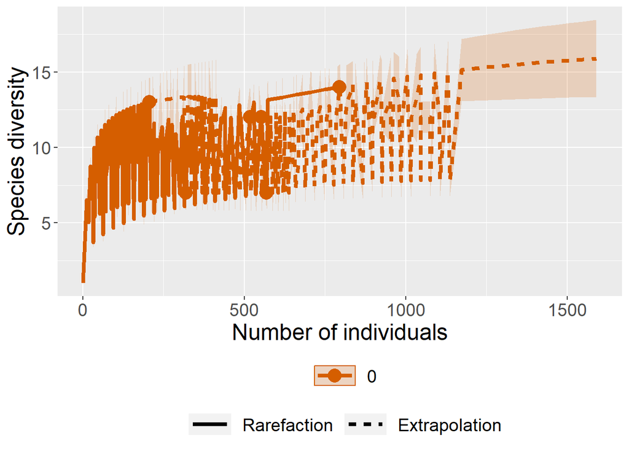

```r
Warton_Data_Graph1 <- ggiNEXT(x = Warton_Data, se=TRUE, color.var="Order.q")

Warton_Data_Graph1
```

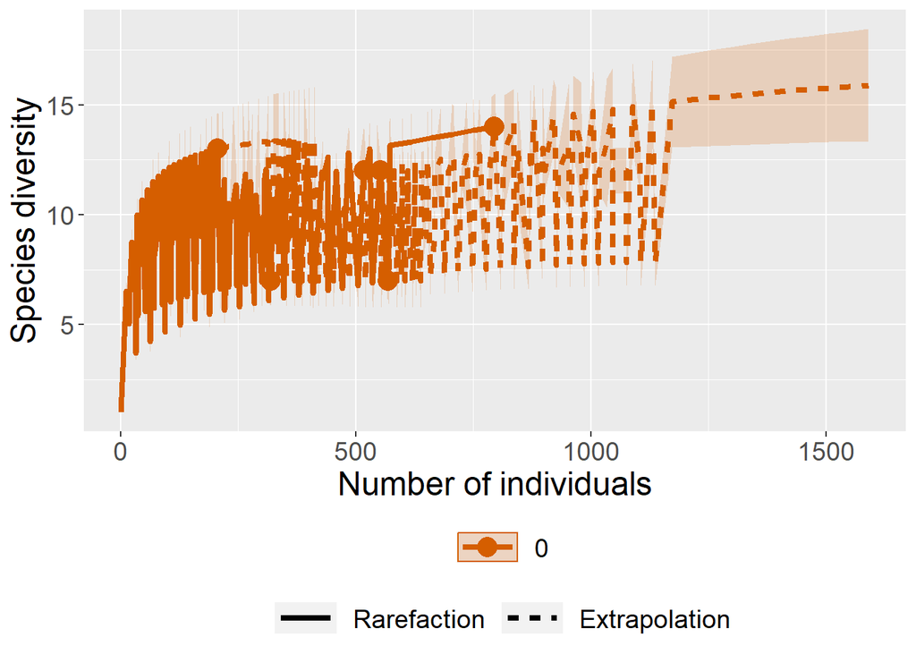

```r
Warton_Data_Graph2 <- ggiNEXT(x = Warton_Data, se=TRUE, type = 1,
                              facet.var="None", color.var="Order.q")

Warton_Data_Graph2
```

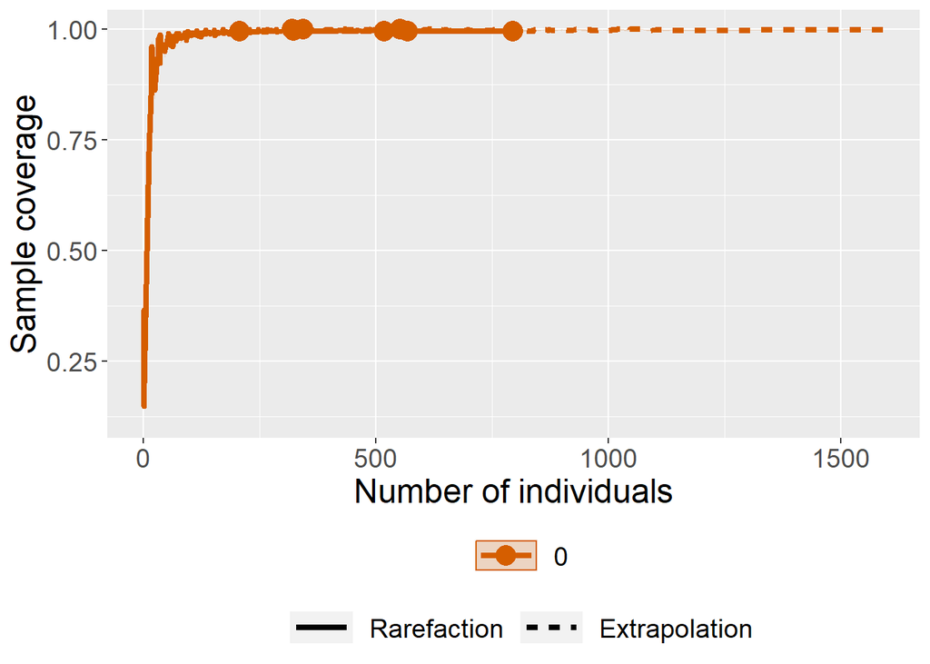

```r
Warton_Data_Graph3 <- ggiNEXT(x = Warton_Data, se=TRUE, type = 2,
                              facet.var="None", color.var="Order.q")

Warton_Data_Graph3
```

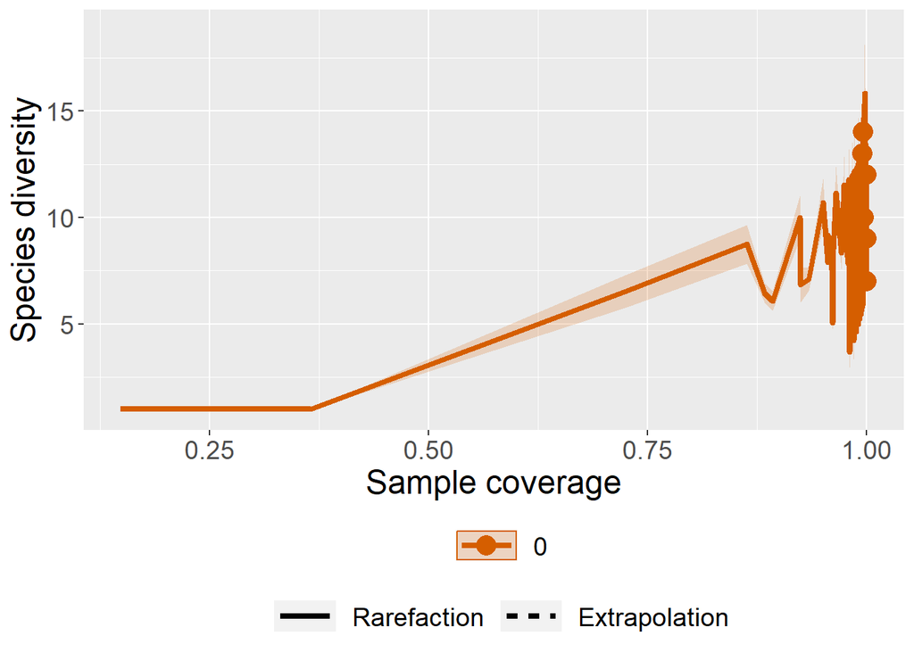

```r
Warton_Data_Graph4 <- ggiNEXT(x = Warton_Data, se=TRUE, type = 3,
                              facet.var="None", color.var="Order.q")

Warton_Data_Graph4
```

##Penicuik##

##Loading Penicuik Data#

```r
urlfile5 <- 'https://raw.githubusercontent.com/Savannankvm/Biodiversity-analyses-for-six-study-sites/PhD-files/Penicuik_Abundance_Data.csv'

Penicuik_Nos <-read.csv(urlfile5)

print(Penicuik_Nos)
```

```
##     Quadrat_1 Quadrat_2 Quadrat_3 Quadrat_4 Quadrat_5
## 1           5         3        32        39         0
## 2           3         0         0         0         0
## 3           0         1         0         0         0
## 4           0         0         0         0         0
## 5           0         1         1         0         0
## 6           0         0         0         0         0
## 7           0         0         0         0         0
## 8           0         0         0         0         0
## 9           0         4         0         0         0
## 10          0         0         0         0         0
## 11          0         0         0         0         0
## 12          0         0         0         0         0
## 13          0         0         0         0         0
## 14          0         0         0         0         0
```

[output cut: 129 more lines]

#colSums to establish sample size for each of the quadrats.

```r
colSums(Penicuik_Nos)
```

```
## Quadrat_1 Quadrat_2 Quadrat_3 Quadrat_4 Quadrat_5
##        76       299       319       324       110
```

#Setting m to sample size for Quadrat 1. This will give me observed #qD value that will be most representative for Quadrat and Community. Will do the same #for the other communities below.

```r
m <- c(76)

Penicuik_Datam <- iNEXT(Penicuik_Nos, q=c(0), datatype= "abundance", size = m)

Penicuik_Datam
```

```
## Compare 5 assemblages with Hill number order q = 0.
## $class: iNEXT
##
## $DataInfo: basic data information
##   Assemblage   n S.obs     SC f1 f2 f3 f4 f5 f6 f7 f8 f9 f10
## 1  Quadrat_1  76     9 0.9610  3  0  4  0  1  0  0  0  0   0
## 2  Quadrat_2 299    14 0.9867  4  0  2  2  0  0  0  0  0   1
## 3  Quadrat_3 319    13 1.0000  1  0  0  4  0  0  0  1  0   1
## 4  Quadrat_4 324     8 1.0000  0  0  0  1  1  0  0  0  0   0
## 5  Quadrat_5 110     5 1.0000  1  0  1  1  0  0  0  0  0   0
##
## $iNextEst: diversity estimates with rarefied and extrapolated samples.
## $size_based (LCL and UCL are obtained for fixed size.)
##
##    Assemblage   m        Method Order.q        qD    qD.LCL    qD.UCL        SC
```

[output cut: 90 more lines]

```r
n <- c(299)

Penicuik_Datan <- iNEXT(Penicuik_Nos, q=c(0), datatype= "abundance", size = n)

Penicuik_Datan
```

```
## Compare 5 assemblages with Hill number order q = 0.
## $class: iNEXT
##
## $DataInfo: basic data information
##   Assemblage   n S.obs     SC f1 f2 f3 f4 f5 f6 f7 f8 f9 f10
## 1  Quadrat_1  76     9 0.9610  3  0  4  0  1  0  0  0  0   0
## 2  Quadrat_2 299    14 0.9867  4  0  2  2  0  0  0  0  0   1
## 3  Quadrat_3 319    13 1.0000  1  0  0  4  0  0  0  1  0   1
## 4  Quadrat_4 324     8 1.0000  0  0  0  1  1  0  0  0  0   0
## 5  Quadrat_5 110     5 1.0000  1  0  1  1  0  0  0  0  0   0
##
## $iNextEst: diversity estimates with rarefied and extrapolated samples.
## $size_based (LCL and UCL are obtained for fixed size.)
##
##    Assemblage   m        Method Order.q        qD    qD.LCL    qD.UCL        SC
```

[output cut: 89 more lines]

```r
o <- c(319)

Penicuik_Datao <- iNEXT(Penicuik_Nos, q=c(0), datatype= "abundance", size = o)

Penicuik_Datao
```

```
## Compare 5 assemblages with Hill number order q = 0.
## $class: iNEXT
##
## $DataInfo: basic data information
##   Assemblage   n S.obs     SC f1 f2 f3 f4 f5 f6 f7 f8 f9 f10
## 1  Quadrat_1  76     9 0.9610  3  0  4  0  1  0  0  0  0   0
## 2  Quadrat_2 299    14 0.9867  4  0  2  2  0  0  0  0  0   1
## 3  Quadrat_3 319    13 1.0000  1  0  0  4  0  0  0  1  0   1
## 4  Quadrat_4 324     8 1.0000  0  0  0  1  1  0  0  0  0   0
## 5  Quadrat_5 110     5 1.0000  1  0  1  1  0  0  0  0  0   0
##
## $iNextEst: diversity estimates with rarefied and extrapolated samples.
## $size_based (LCL and UCL are obtained for fixed size.)
##
##    Assemblage   m        Method Order.q        qD    qD.LCL    qD.UCL        SC
```

[output cut: 90 more lines]

```r
p <- c(324)

Penicuik_Datap <- iNEXT(Penicuik_Nos, q=c(0), datatype= "abundance", size = p)

Penicuik_Datap
```

```
## Compare 5 assemblages with Hill number order q = 0.
## $class: iNEXT
##
## $DataInfo: basic data information
##   Assemblage   n S.obs     SC f1 f2 f3 f4 f5 f6 f7 f8 f9 f10
## 1  Quadrat_1  76     9 0.9610  3  0  4  0  1  0  0  0  0   0
## 2  Quadrat_2 299    14 0.9867  4  0  2  2  0  0  0  0  0   1
## 3  Quadrat_3 319    13 1.0000  1  0  0  4  0  0  0  1  0   1
## 4  Quadrat_4 324     8 1.0000  0  0  0  1  1  0  0  0  0   0
## 5  Quadrat_5 110     5 1.0000  1  0  1  1  0  0  0  0  0   0
##
## $iNextEst: diversity estimates with rarefied and extrapolated samples.
## $size_based (LCL and UCL are obtained for fixed size.)
##
##    Assemblage   m        Method Order.q        qD    qD.LCL    qD.UCL        SC
```

[output cut: 90 more lines]

```r
q <- c(110)

Penicuik_Dataq <- iNEXT(Penicuik_Nos, q=c(0), datatype= "abundance", size = q)

Penicuik_Dataq
```

```
## Compare 5 assemblages with Hill number order q = 0.
## $class: iNEXT
##
## $DataInfo: basic data information
##   Assemblage   n S.obs     SC f1 f2 f3 f4 f5 f6 f7 f8 f9 f10
## 1  Quadrat_1  76     9 0.9610  3  0  4  0  1  0  0  0  0   0
## 2  Quadrat_2 299    14 0.9867  4  0  2  2  0  0  0  0  0   1
## 3  Quadrat_3 319    13 1.0000  1  0  0  4  0  0  0  1  0   1
## 4  Quadrat_4 324     8 1.0000  0  0  0  1  1  0  0  0  0   0
## 5  Quadrat_5 110     5 1.0000  1  0  1  1  0  0  0  0  0   0
##
## $iNextEst: diversity estimates with rarefied and extrapolated samples.
## $size_based (LCL and UCL are obtained for fixed size.)
##
##    Assemblage   m        Method Order.q        qD    qD.LCL    qD.UCL        SC
```

[output cut: 91 more lines]

#Now to run the analysis again without specificying the size, can do this for #looking at the other diversity indices

```r
Penicuik_Data <- iNEXT(Penicuik_Nos, q=c(0), datatype= "abundance")

print(Penicuik_Data)
```

```
## Compare 5 assemblages with Hill number order q = 0.
## $class: iNEXT
##
## $DataInfo: basic data information
##   Assemblage   n S.obs     SC f1 f2 f3 f4 f5 f6 f7 f8 f9 f10
## 1  Quadrat_1  76     9 0.9610  3  0  4  0  1  0  0  0  0   0
## 2  Quadrat_2 299    14 0.9867  4  0  2  2  0  0  0  0  0   1
## 3  Quadrat_3 319    13 1.0000  1  0  0  4  0  0  0  1  0   1
## 4  Quadrat_4 324     8 1.0000  0  0  0  1  1  0  0  0  0   0
## 5  Quadrat_5 110     5 1.0000  1  0  1  1  0  0  0  0  0   0
##
## $iNextEst: diversity estimates with rarefied and extrapolated samples.
## $size_based (LCL and UCL are obtained for fixed size.)
##
##     Assemblage   m        Method Order.q        qD    qD.LCL    qD.UCL
```

[output cut: 144 more lines]

```r
summary(Penicuik_Data)
```

```
##          Length Class      Mode
## DataInfo 14     data.frame list
## iNextEst  2     -none-     list
## AsyEst    7     data.frame list
```

#Now to do obtain additional biodiversity indices, including sample coverage, for Penicuik#

```r
P1 <- diversity(Penicuik_Nos$Quadrat_1)

Penicuik2 <- estimateD(Penicuik_Nos, q = c(0,1,2), datatype = "abundance", base="coverage")
Penicuik2
```

```
##    Assemblage         m        Method Order.q        SC        qD    qD.LCL
## 1   Quadrat_1 152.00000 Extrapolation       0 0.9857643 10.878614  2.098538
## 2   Quadrat_1 152.00000 Extrapolation       1 0.9857643  3.109637  2.291375
## 3   Quadrat_1 152.00000 Extrapolation       2 0.9857643  1.814739  1.467261
## 4   Quadrat_2 242.30416   Rarefaction       0 0.9857643 13.226103  6.976844
## 5   Quadrat_2 242.30416   Rarefaction       1 0.9857643  5.232833  4.433015
## 6   Quadrat_2 242.30416   Rarefaction       2 0.9857643  3.544925  2.975373
## 7   Quadrat_3 130.77377   Rarefaction       0 0.9857643 11.911443 10.727849
## 8   Quadrat_3 130.77377   Rarefaction       1 0.9857643  6.737450  6.100970
## 9   Quadrat_3 130.77377   Rarefaction       2 0.9857643  4.996346  4.344544
## 10  Quadrat_4  71.11103   Rarefaction       0 0.9857643  7.281229  6.722664
## 11  Quadrat_4  71.11103   Rarefaction       1 0.9857643  5.383352  4.975928
## 12  Quadrat_4  71.11103   Rarefaction       2 0.9857643  4.547625  4.107702
## 13  Quadrat_5  69.58026   Rarefaction       0 0.9857643  4.568704  3.312696
## 14  Quadrat_5  69.58026   Rarefaction       1 0.9857643  2.606841  2.226482
```

[output cut: 17 more lines]

#Now for vegan analyses to determine species eveness for Penicuik data

```r
Pevenness1 <- P1/log(specnumber(Penicuik_Nos$Quadrat_1))

summary(Pevenness1)
```

```
##    Min. 1st Qu.  Median    Mean 3rd Qu.    Max.
##   0.494   0.494   0.494   0.494   0.494   0.494
```

```r
P2 <- diversity(Penicuik_Nos$Quadrat_2)

Pevenness2 <- P2/log(specnumber(Penicuik_Nos$Quadrat_2))

summary(Pevenness2)
```

```
##    Min. 1st Qu.  Median    Mean 3rd Qu.    Max.
##  0.6296  0.6296  0.6296  0.6296  0.6296  0.6296
```

```r
P3 <- diversity(Penicuik_Nos$Quadrat_3)

Pevenness3 <- P3/log(specnumber(Penicuik_Nos$Quadrat_3))

summary(Pevenness3)
```

```
##    Min. 1st Qu.  Median    Mean 3rd Qu.    Max.
##  0.7557  0.7557  0.7557  0.7557  0.7557  0.7557
```

```r
P4 <- diversity(Penicuik_Nos$Quadrat_4)

Pevenness4 <- P4/log(specnumber(Penicuik_Nos$Quadrat_4))

summary(Pevenness4)
```

```
##    Min. 1st Qu.  Median    Mean 3rd Qu.    Max.
##  0.8298  0.8298  0.8298  0.8298  0.8298  0.8298
```

```r
P5 <- diversity(Penicuik_Nos$Quadrat_5)

Pevenness5 <- P5/log(specnumber(Penicuik_Nos$Quadrat_5))

summary(Pevenness5)
```

```
##    Min. 1st Qu.  Median    Mean 3rd Qu.    Max.
##  0.6036  0.6036  0.6036  0.6036  0.6036  0.6036
```

#Now for data visualisation for Penicuik data, including the generation of species curve graphs#

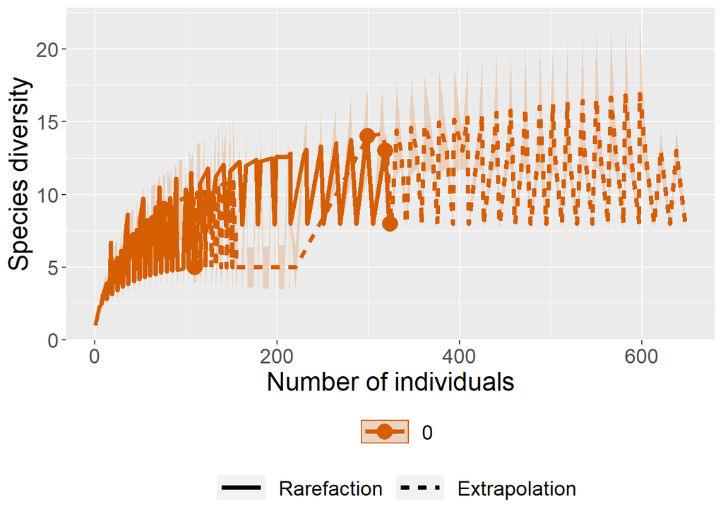

```r
Penicuik_Data_Graph1 <- ggiNEXT(x = Penicuik_Data, se=TRUE, color.var="Order.q")

Penicuik_Data_Graph1
```

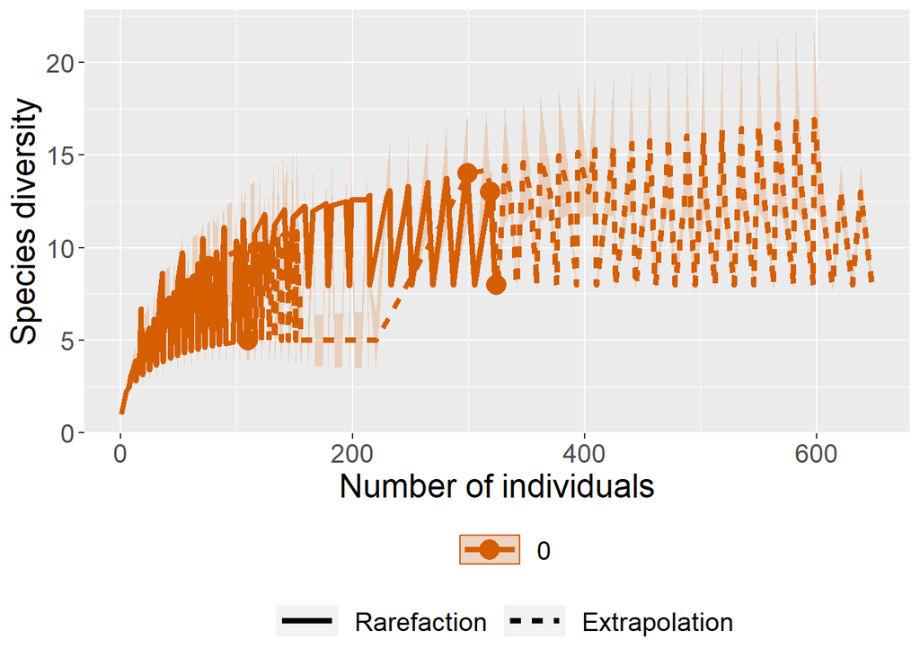

```r
Penicuik_Data_Graph2 <- ggiNEXT(x = Penicuik_Data, se=TRUE, type = 1,
                                facet.var="None", color.var="Order.q")

Penicuik_Data_Graph2
```

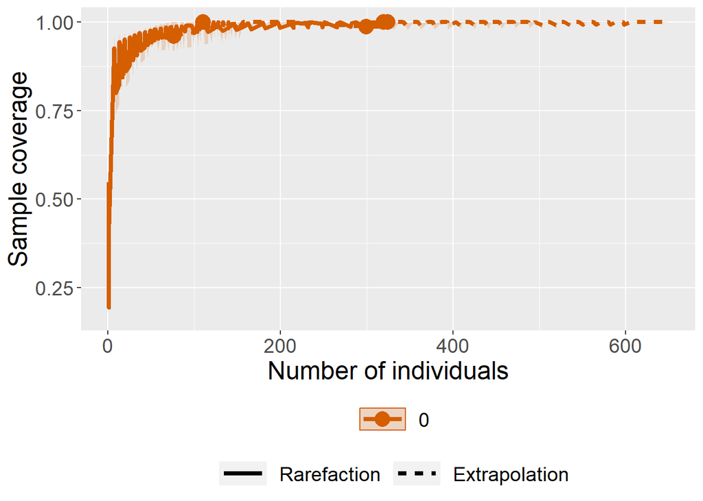

```r
Penicuik_Data_Graph3 <- ggiNEXT(x = Penicuik_Data, se=TRUE, type = 2,
                                facet.var="None", color.var="Order.q")

Penicuik_Data_Graph3
```

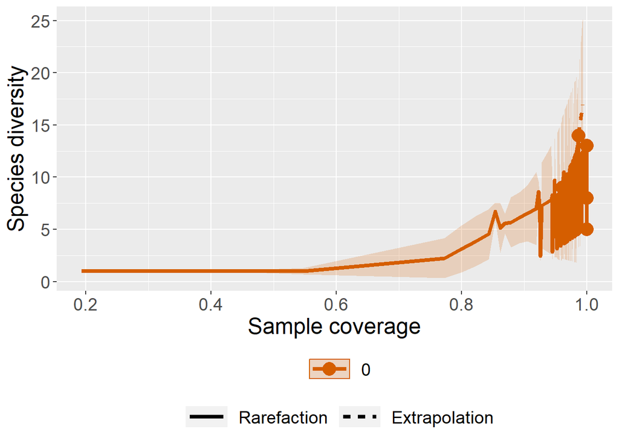

```r
Penicuik_Data_Graph4 <- ggiNEXT(x = Penicuik_Data, se=TRUE, type = 3,
                                facet.var="None", color.var="Order.q")

Penicuik_Data_Graph4
```